# Effects of water deficit combined with soil texture, soil bulk density and tomato variety on tomato fruit quality: A meta-analysis - ScienceDirect

[Advanced](https://www.sciencedirect.com/search)

## Outline

1. Highlights
2. Abstract
3. Keywords
4. 1. Introduction
5. 2. Materials and methods
6. 3. Results
7. 4. Discussion
8. 5. Conclusions
9. Declaration of Competing Interest
10. Acknowledgement
11. References

## Figures (13)

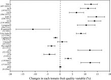

## Tables (1)

1. Table 1

## [Agricultural Water Management](https://www.sciencedirect.com/science/journal/03783774)

[Volume 243](https://www.sciencedirect.com/science/journal/03783774/243/supp/C), 1 January 2021, 106427

# Effects of water deficit combined with soil texture, soil bulk density and tomato variety on tomato fruit quality: A meta-analysis

[JiaLu<sup>a</sup>](https://www.sciencedirect.com/science/article/pii/S0378377420309276#!)[GuangchengShao<sup>a</sup>](https://www.sciencedirect.com/science/article/pii/S0378377420309276#!)[YangGao<sup>a</sup>](https://www.sciencedirect.com/science/article/pii/S0378377420309276#!)[KunZhang<sup>a</sup>](https://www.sciencedirect.com/science/article/pii/S0378377420309276#!)[QunWei<sup>b</sup>](https://www.sciencedirect.com/science/article/pii/S0378377420309276#!)[JifanCheng<sup>a</sup>](https://www.sciencedirect.com/science/article/pii/S0378377420309276#!)

https://doi.org/10.1016/j.agwat.2020.106427[Get rights and content](https://s100.copyright.com/AppDispatchServlet?publisherName=ELS&contentID=S0378377420309276&orderBeanReset=true)

## Highlights

**•**

Deficit irrigation increased most of tomato quality variables.

**•**

Soil texture had effects on the response of tomato quality to water deficit.

**•**

Soil bulk density had effects on the response of tomato quality to water deficit.

**•**

Tomato quality had different responses to water deficit among varieties.

## Abstract

Tomato is a popular healthy fruit worldwide because it is rich in secondary metabolites such as vitamin C. Deficit irrigation (DI) can be applied to improve tomato fruit quality to a certain degree and save water consumption. However, the effects of DI on tomato quality are complex and affected by factors such as tomato variety and soil bulk density and texture. The objective of this paper is to use meta-analysis to 1) investigate the effects of DI on tomato quality variables and 2) study how soil texture, soil bulk density and three tomato varieties affect quality variables under DI compared to those under full irrigation. We collected 83 research papers from around the world and analyzed 2369 data pairs. Overall, DI increased the total soluble solids (12.44%), soluble sugar (11.23%), organic acids (6.58%), sugar/acid content ratio (14.56%), vitamin C (13.84%), lycopene (10.46%), color index (8.42%), red-green value (11.89%), shape index (3.25%) and firmness (12.09%) while decreasing β-carotene, lightness, hue angle and yellow-blue value by 11.11%, 1.77%, 3.42% and 4.26%, respectively. In addition, DI had no significant effects on tomato chroma (0.89% on average; 95% CI: -0.96% to 2.79%) or pH (0.13% on average; 95% CI: -0.26% to 0.52%). The results indicated that it would be better to apply deficit irrigation in fine and coarse soil, because most of the quality variables improved more in these soil textures than in medium soil. Soil with a bulk density of 1.2∼1.4 g cm<sup>-3</sup> benefited taste quality, vitamin C and shape index. The quality of the three tomato varieties responded differently to water deficit conditions. Moreover, cherry tomato responded better to water deficit conditions than the other two tomato varieties; four quality variables improved the most in cherry tomato and two other variables were also improved. Our findings could help to obtain a better understanding of how fruit quality responds to DI in different soil textures, soil bulk densities and tomato varieties and to produce higher-quality tomatoes.

## Keywords

Tomato fruit quality

Deficit irrigation

Soil texture

Soil bulk density

Tomato varieties

## 1. Introduction

It is well known that a healthy diet is helpful in preventing chronic diseases such as cancer and cardiovascular and neurodegenerative diseases, improving energy levels and managing weight (Dorais et al., 2008). Studies have shown that tomato consumption has strong inverse relationships with the risks of certain types of cancer (Sesso et al., 2004; Stahl and Sies, 2005). Many clinical trials and experiments have proven that tomatoes are rich in antioxidants and vitamin C, which can protect humans and animals from these diseases (Mayne, 1996). In addition, tomato is a popular vegetable (Battilani et al., 2012) with a plant world wide area of 4.76 × 10<sup>6</sup> ha in 2018, and a production of 182.26 × 10<sup>6</sup> ha (FAOSTAT, 2018). Tomato not only helps ensure the security of global food but it is also an important source of antioxidants such as lycopene, phenolic and vitamin C in human diet (Toor et al., 2006). Sustaining tomato yields and improving fruit quality are very important to support environmental sustainability and ensure human health. However, traditional tomato irrigation uses large amounts of water, and climate change decreases the renewable surface water and groundwater resources in most dry subtropical regions, intensifying competition for water demand among different social industries (IPCC, 2014). To solve this problem, developing water-saving practices is a key strategy which could improve fruit quality with acceptable yield losses.

Deficit irrigation (DI) is a good way to produce environmentally sustainable food and save water; this method applies water below the amount of the plant’s water demand as indicated by evapotranspiration (ET) (Willett et al., 2019). DI not only has the potential to reduce water consumption (Chai et al., 2016; Kang et al., 2017) but also to regulate fruit quality (Nuruddin et al., 2003; Ripoll et al., 2014). The application of the DI strategy has succeeded in fruit tress (dos Santos et al., 2007; Yang et al., 2011) and cereals (Li et al., 2015; Talebnejad and Separskhah, 2015). Many studies have indicated that certain water deficit could improve some quality variables, such as total soluble solids and vitamin C (Zegbe-Domınguez et al., 2003; Ozbahce and Tari, 2010; Lu et al., 2019). Water deficit in the fruit development stage could also increase the total phenolic content in tomato (Barbagallo et al., 2013). Favati et al. (2009) studied the effects of irrigation management on tomato quality and observed that the accumulation of lycopene and β-carotene under water deficit was higher than that without water deficit. In addition, certain water deficit levels were demonstrated in experiments to have the potential to improve water use efficiency (Agbemafle et al., 2014; Zhang et al., 2017).

Although deficit irrigation has many benefits in certain tomato quality variables, its effects are complex, despite much studies (Renquist and Reid, 2001; Marouelli and Silva, 2007). Many factors affect tomato nutrients, including variety, climate, light, temperature, soil, fertilization, and water status (Smith and Hui, 2004). In addition, many factors alter the response of tomato to water deficit. Ripoll et al. (2016) studied the effects of different degrees of water deficit on tomato quality and found that high levels of deficit irrigation may reduce the sugar, acid and carotenoid contents. Wang et al. (2011b) indicated the water deficit period significantly affected the effects of deficit irrigation on tomato quality. Soil properties, including chemical, physical and biological properties, affect water and mineral uptake by plants, thus influencing tomato quality under water deficit (Dorais et al., 2008). Bogale et al. (2016) studied the effects of regulated deficit irrigation on bioactive compounds and antioxidant activity in two selected tomato cultivars, and the results showed that vitamin C and lycopene contents significantly increased in the Matina variety but not in the Cochoro variety. Climate is also an important factor; the evaporative demand on the crop strongly influences the effects of deficit irrigation (Patanè et al., 2011).

Though many studies have investigated the effects of water deficit on tomato quality, many factors influence the response of tomato quality to water deficit, as discussed above. It is important to understand what the effects will be under water deficit in different conditions and to correctly apply a water-saving strategy for a better-quality tomato. Moreover, few studies have investigated the effects of water deficit on tomato quality in different soil textures and at different soil bulk densities. Thus, further studies that take soil properties and tomato varieties into consideration are required, to obtain a better understanding of their influences on tomato quality. The objective of this study was to use a meta-analysis to 1) quantify the effects of water deficit on tomato quality parameters such as total soluble solids, soluble sugar, vitamin C, lycopene, firmness, and color and 2) identify how different factors, including soil texture, soil bulk density and tomato variety, influenced the effects of water deficit on tomato fruit quality.

## 2. Materials and methods

### 2.1. Data collection

Data were collected through a comprehensive literature search on the ISI Web of Science, Science Direct and China National Knowledge Internet for studies reporting the effects of water deficit on tomato quality published from April 1960 to October 2019. In addition, a second search was performed by reading references of already downloaded articles. The following key words were focused on during the whole literature search: tomato quality, deficit irrigation, regulated deficit irrigation, water stress, water deficit, and irrigation regime. Studies that reported the effects of deficit irrigation on tomato quality compared with those of a control treatment without deficit irrigation (CK) in pot or field experiments were selected. Here, the DI strategy mainly refers to applying water at a rate lower than the plant water demand. The detailed treatments were presented in Table 1. Treatments were set based on an index of the following parameters: crop evapotranspiration (ETc), reference evapotranspiration (ETr), pan evaporation (Ep), field water capacity (θf), soil water suction, and leaf water potential. In a few papers, the control treatment was irrigated according to the experience of local growers, and the irrigation water needed in some papers was calculated according to a specific function. The treatments presented in Table 1 represent only the degree of deficit irrigation, because the detail application of the DI may be performed with different application times.

Table 1. Overview of the studies used for analysis.

| Author and date | Country | Soil texture | Soil bulk density/cm<sup>-3</sup> | Tomato variety | Deficit irrigation treatments |
| --- | --- | --- | --- | --- | --- |
| Abdel-Razzak et al., 2016 | Saudi Arabia | C | N | cherry | 0.50ETc, 0.75ETc, 1.00ETc (CK) |
| Agbna et al., 2017 | China | M | 1.35 | N | 0.50ETr, 0.75ETr, 1.00ETr (CK) |
| Bakr et al., 2017 | Hungary | C | 1.57 | processing | NI, 0.50CK, CK |
| Barbagallo et al., 2013 | Italy | C | N | processing | NI, 1.00ETc (CK) |
| Birhanu and Tilahun, 2010 | Ethiopia | M | N | N | 0.25ETc, 0.50ETc, 0.75ETc, 1.00ETc (CK) |
| Bogale et al., 2016 | Germany | A | N | prcessing/N | 0.50CK, CK |
| Cantore et al., 2016 | Italy | C | 1.28 | cherry | rain fed, 0.50ETc, 1.00ETc (CK) |
| Casa and Rouphael, 2014 | Italy | M | 1.10 | processing | 0.50ETc, 1.00ETc (CK) |
| Chen, 2006 | China | N | 1.32 | processing | 0.40∼0.45θf, 0.55∼0.60θf, 0.70∼0.75θf, 0.85∼0.90θf (CK) (irrigation lower limit), 0.90θf (irrigation upper limit) |
| Chen et al., 2014 | China | C | 1.45 | pink | 1/3CK, 4/9CK, 2/3CK, 8/9CK, CK (0.75∼0.90θf) |
| Colla et al., 1999 | Italy | C | N | processing | 0.50ETc, 0.75ETc, 1.00ETc (CK) |
| Coyago-Cruz et al., 2017 | Spain | N | N | N | 55.10 mm, CK (1.00ETc) |
| Coyago-Cruz et al., 2019 | Spain | M | N | cherry | irrigation threshold maintained at −1 MPa leaf water potential, CK (1.00ETc) |
| Djurović et al., 2016 | Serbia | M | N | N | 0.50ETc, 1.00ETc (CK) |
| Du et al., 2017 | China | N | 1.27 | N | 0.50Ep, 0.75Ep, 1.00Ep (CK) |
| Favati et al., 2009 | Italy | M | 1.25 | processing | 0.50ETc, 1.00ETc (CK) |
| Fullana-Pericàs et al., 2019 | Spain | F | N | processing/cherry/N | cut off, CK (1.00ETc) |
| Gao, 2006 | China | M | N | processing | 0.50θf, 0.65θf, 0.80θf (CK) (maintained soil moisture content) |
| Giuliani et al., 2016 | Italy | F | N | processing | NI, 0.60ETc, 0.80ETc, 1.00ETc (CK) |
| Giuliani et al., 2017 | Italy | M | N | processing | NI, 0.70CK, CK (1.00ETc) |
| Giuliani et al., 2019 | Italy | M | 1.13 | processing | 0.75CK, CK (1.00ETc) |
| Gong et al., 2016 | China | M | 1.47 | N | 0.50Ep, 0.70Ep, 0.90Ep (CK) |
| Gong et al., 2017 | China | M | 1.47 | N | 0.50Ep, 0.70Ep, 0.90Ep (CK) |
| Guida et al., 2017 | Italy | M | 1.07 | N | rain fed, CK (1.00ETc) |
| Guo et al., 2007 | China | N | N | pink | 0.45∼0.55θf, 0.55∼0.65θf, 0.65∼0.75θf (CK) (irrigation upper limit), 0.40∼0.45θf (irrigation lower limit at bloom and fruit setting stage); 0.55∼0.65θf, 0.65∼0.75θf, 0.75∼0.85θf (CK) (irrigation upper… |
| Guo, 2007 | China | N | 1.38 | pink | the same treatment as the above paper of Guo et al. (2007) |
| Guo et al., 2014 | China | N | 1.50 | processing | 0.45∼0.55θf, 0.55∼0.65θf, 0.65∼0.75θf (CK) (maintained soil moisture content) |
| Hao et al., 2019 | China | M | 1.30 | pink | 0.40∼0.50θf, 0.50∼0.60θf, 0.70∼0.80θf (CK) (maintained soil moisture content) |
| Hartz et al., 2006 | America | C/F | N | processing | 25∼50% reduced compared with CK, CK |
| Jiang and Zhao, 2019 | China | C | 1.38/1.4 | N | 1/3CK, 2/3CK, CK (0.75θf∼0.90θf) |

[output cut: 53 more lines]

Note: Country stands for the place where the experiment was carried out; Soil texture (A = mixtures of some materials, C = coarse soil, F = fine soil, M = medium soil, N = data not available); Variety ('cherry, pink and processing' stand for 'cherry tomato, pink tomato and processing tomato' respectively, N = data not available); CK stands for the treatment without deficit irrigation; ETc stands for crop evapotranspiration; Ep stands for pan evaporation; ETr stands for the reference evapotranspiration; Rain fed treatment is irrigated only at crop establishment and then irrigated by the rain; “Cut off” means no irrigation supply to tomato at appointed time; NI stands for no irrigation after plant establishment; θf means field water capacity.

The tomato quality variables analyzed included total soluble solids (TSS) (soluble solids were discussed in some papers, and we included this variable in total soluble solids); soluble sugar (SS); organic acids (OA); sugar/acid content ratio (SAR); vitamin C (VC); lycopene; β-carotene; color parameters (lightness, chroma, hue angle, a*, b*), a* indicates green/red shade, b* indicates blue/yellow shade; color index, calculated following the equation color index = 2000 a/[L(a<sup>2</sup>+b<sup>2</sup>)<sup>0.5</sup>] (Intelmann et al., 2005); shape index (SI); firmness (Fn); and tomato pH. We classified the variables above into categories as follows: (1) taste quality variables, including TSS, SS, OA and SAR; (2) VC and carotenoids (lycopene and β-carotene); (3) external quality, SI and color parameters (lightness, chroma, hue angle, a*, and b*); (4) storage quality, including Fn; and (5) tomato pH. In order to analyze the factors that affected the response of tomato quality to water deficit, we also collected variables including soil texture, soil bulk density and tomato variety. According to Soil Taxonomy (Soil Survey Staff, 2014), we classified the soil texture into three groups: (1) coarse soil (C), including sandy loam, sandy clay loam and loamy sand; (2) medium soil (M), including clay loam, silty clay loam, silt and silt loam; and (3) fine soil (F), including clay, silt clay and sandy clay. Alameda et al. (2012) found that the control treatment growth increased with soil compaction up to bulk density values of approximately 1.4 g cm<sup>-3</sup> and then declined, which showed that at low to intermediate values, soil compaction could stimulate growth. Based on this, we divided all data groups into three subgroups: (1) soil bulk density values ≥ 1.4 g cm<sup>-3</sup>; (2) soil bulk density values ≥ 1.2 g cm<sup>-3</sup> & < 1.4 g cm<sup>-3</sup> (1.2∼1.4 g cm<sup>-3</sup>); and (3) soil bulk density values < 1.2 g cm<sup>-3</sup>. Several different tomato varieties were used in the experiments in the collected research articles, but cherry tomato, processing tomato and pink tomato accounted for a large proportion of the varieties. If the data were classified based on the different tomato varieties, some subgroup data would have come from fewer than two papers. Thus, we only discussed the three subgroups of tomato varieties. The data for the subgroups analyzed were from at least two papers, otherwise the subgroup was not discussed in this paper.

To avoid publication bias, the following criteria were used to select studies: (1) at least one of the collected tomato quality variables was measured; (2) how the studies carried out deficit irrigation and the control treatment were described in detail; and (3) the mean value, standard deviation (SD), and n (the number of replicates) for both the treatment and control groups were provided; these data were needed to perform the meta-analysis. If there were missing data, we tried to contact the authors to obtain the needed data. If the data were shown in figures, we extracted the data through GetData Graph Digitizer 2.26 (http://www.getdatagraph-digitizer.com/index.php). If the standard error (SE) was given but the SD was not, we converted the SE to SD by the formula as $SD=SE×n$ (Jian et al., 2016). If the contacted authors did not answer, the variances were interpolated as the coefficient of all the variances of the experimental means from the paper by multiplying by the treatment means; moreover, to reduce the weighting of these studies, we doubled the variance (Jeffery et al., 2017).

After the searches and selection, we finally used 83 papers and 2369 data pairs to analyze the effects of water deficit on tomato fruit quality. As shown in Table 1, most of the studies were from Asia (55.42%), followed by Europe (32.53%), North America (6.02%), Oceania (3.62%), and Africa (2.41%).

### 2.2. Data analysis

The meta-analysis was performed in R software, which is a free software environment for statistical analysis and graphics. The response ratio ($Ri$) was used as the measure of the effect size and was calculated by the following formula for each pair of data (Hedges et al., 1999):$Ri=xt/xc$where $xt$ is the mean of the treatment group variables and $xc$ is the mean of the control group variables, while the value range of i = 1, 2, …, k, representing the *i<sup>th</sup>* independent paired data.

The weight ($Wi$) of each paired data is calculated with the following formula in the random-effects model, it is the weighted factor of effect size i:$Wi=1Vi*$where $Vi*$ is the sum of the variance among all data ($T2$) and the internal variance of the *i<sup>th</sup>* paired data ($Vi$), that is $Vi*=Vi+T2$.

The relative weight ($Wi'$) was calculated by the following formula, and it represented the percentage of result of each paired data in the overall result:$Wi'=Wi∑i=1kWi$

The whole effect size $R*$ is calculated by the following formula:$R*=∑i=1kWiRi∑i=1kWi$

In this way, studies with lower variance were given greater weights to calculate $R*$ so as to increase the precision of the effect size.

Higgins I<sup>2</sup> statistics and the Q test (Higgins et al., 2003) were used to assess the degree of heterogeneity to indicate the variance between studies. A fixed-effects model was used for low-heterogenous studies (I<sup>2</sup> ≤ 50% and P > 0.05), and a random-effects model was used in the opposite situation (I<sup>2</sup> > 50% or P < 0.05). A forest plot was generated from the pooled results. In the forest plot, the mean ratio response and the 95% confidence interval (CI) were represented by a point and bars, respectively. To explain the results, we obtained the percentage of the change compared to the control treatment ([R-1] × 100%). If the 95% CI did not overlap with zero, we considered the effect size to be significantly different from the control. If the 95% CIs of the subgroups did not overlap, we considered the effect size significantly different between subgroups.

## 3. Results

### 3.1. Overall effect of water deficit on tomato fruit quality

Fig. 1 shows the overall effect of water deficit on each quality variable. We found water deficit significantly improved most of the quality variables, except for chroma and juice pH, and significantly decreased the quality variables of β-carotene and hue angle, lightness and b*. In detail, water deficit significantly improved TSS by 12.44% (95% CI: 9.92% to 15.01%) according to 497 paired comparisons, SS by 11.23% (95% CI: 8.21% to 14.34%, 197 paired comparisons), OA by 6.58% (95% CI: 3.72% to 9.52%, 386 paired comparisons), and SAR by 14.56% (95% CI: 11.27% to 17.94%, 220 paired comparisons). VC significantly increased under deficit irrigation, by 13.84% (95% CI: 11.32% to 16.42%, 319 paired comparisons). For carotenoids, lycopene increased by 10.46% (95% CI: 6.94% to 14.10%, 204 paired comparisons). However, β-carotene decreased significantly, by 11.11% (95% CI: -17.60% to -4.11%, 52 paired comparisons). For the fruit chromatic parameters, water deficit significantly increased the color index by 8.42% (95% CI: 6.54% to 10.33%, 127 paired comparisons) and a* value by 11.89% (95% CI: 7.20% to 16.79%, 52 paired comparisons). In contrast, lightness decreased by 1.77% (95% CI: -2.47% to -1.06%, 70 paired comparisons), and the b* value decreased by 4.26% (95% CI: -6.54% to -1.92%, 31 paired comparisons). There was no significant difference in tomato chroma under water deficit (0.89%; 95% CI: -0.96% to 2.79%). The hue angle decreased significantly, by 3.42% (% CI: -4.86% to -1.96%). SI was increased significantly, by 3.25% (95% CI: 1.99% to 4.53%, 119 paired comparisons). Based on 171 data pairs, the storage quality (Fn) was significantly enhanced by 12.09% (95% CI: 8.34% to 15.96%) under water deficit. Water deficit had no significant effect on the tomato juice pH (0.13%; 95% CI: -0.26% to 0.52%).

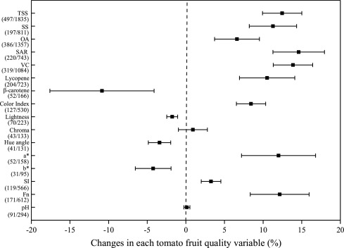

1. [Download : Download high-res image (178KB)](https://ars.els-cdn.com/content/image/1-s2.0-S0378377420309276-gr1_lrg.jpg)
2. [Download : Download full-size image](https://ars.els-cdn.com/content/image/1-s2.0-S0378377420309276-gr1.jpg)

Fig. 1. The average change in each tomato fruit quality variable in response to deficit irrigation. Points stand for the mean effect, and bars represent 95% confidence intervals. Numbers in parenthesis in the left column show the number of data pairs (left) and the total number of replicates (right) for each analysis. TSS, SS, OA, SAR, VC, a*, b*, SI and Fn stand for total soluble solids, soluble sugar, organic acids, sugar/acid content ratio, vitamin C, value of red-green, value of yellow-blue, shape index and firmness respectively.

### 3.2. Effects of water deficit on tomato taste quality in different soil textures, soil bulk densities and tomato varieties

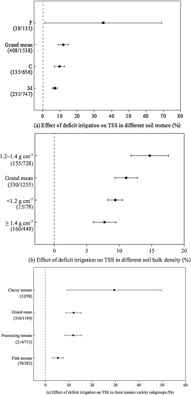

1. [Download : Download high-res image (310KB)](https://ars.els-cdn.com/content/image/1-s2.0-S0378377420309276-gr2_lrg.jpg)
2. [Download : Download full-size image](https://ars.els-cdn.com/content/image/1-s2.0-S0378377420309276-gr2.jpg)

Fig. 2. Effect of deficit irrigation on total soluble solids (TSS) in different soil texture, soil bulk density and tomato variety groups. Points stand for the mean effect, and bars represent 95% confidence intervals. Numbers in parenthesis in the left column show the number of data pairs (left) and the total number of replicates (right) for each analysis. Soil texture (C = coarse soil, F = fine soil, M = medium soil).

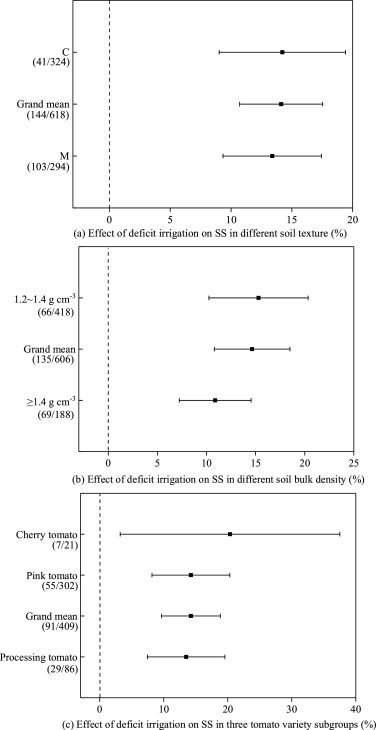

1. [Download : Download high-res image (271KB)](https://ars.els-cdn.com/content/image/1-s2.0-S0378377420309276-gr3_lrg.jpg)
2. [Download : Download full-size image](https://ars.els-cdn.com/content/image/1-s2.0-S0378377420309276-gr3.jpg)

Fig. 3. Effect of deficit irrigation on soluble sugar (SS) in different soil texture, soil bulk density and tomato variety groups. Points stand for the mean effect, and bars represent 95% confidence intervals. Numbers in parenthesis in the left column show the number of data pairs (left) and the total number of replicates (right) for each analysis. Soil texture (C = coarse soil, M = medium soil).

As shown in Fig. 4(a), there was no change in the OA level in coarse soil (95% CI: -1.20% to 9.37%) under water deficit, while it significantly increased, by 9.86%, in fine soil (95% CI: 3.62% to 16.47%, 19 paired comparisons) and by 8.02% in medium soil (95% CI: 5.53% to 10.58%, 174 paired comparisons). Fig. 4(b) indicates that soil bulk density influenced the OA response to water deficit. OA significantly increased, by 8.58%, in ≥ 1.4 g cm<sup>-3</sup> bulk density soil and by 7.04% in < 1.2 g cm<sup>-3</sup> bulk density soil with 125 and 15 paired comparisons, respectively, while it did not change in the other subgroup (95% CI: -3.62% to 7.51%). The response of OA to water deficit differed among tomato varieties (Fig. 4(c)), with increases of 11.92% (95% CI: 8.08% to 15.91%), 7.25% (95% CI: 3.32% to 11.34%) and no change (95% CI: -4.06% to 9.32%) in cherry tomato, processing tomato and pink tomato, respectively.

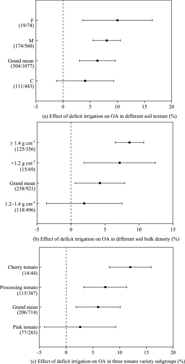

1. [Download : Download high-res image (287KB)](https://ars.els-cdn.com/content/image/1-s2.0-S0378377420309276-gr4_lrg.jpg)
2. [Download : Download full-size image](https://ars.els-cdn.com/content/image/1-s2.0-S0378377420309276-gr4.jpg)

Fig. 4. Effect of deficit irrigation on organic acids (OA) in different soil texture, soil bulk density and tomato variety groups. Points stand for the mean effect, and bars represent 95% confidence intervals. Numbers in parenthesis in the left column show the number of data pairs (left) and the total number of replicates (right) for each analysis. Soil texture (C = coarse soil, F = fine soil, M = medium soil).

Both soil texture and bulk density had significant effects on tomato SAR under water deficit, as shown in Fig. 5, while tomato variety did not. As shown in Fig. 5(a), SAR increased significantly more in coarse soil (29.42%; 95% CI: 20.91% to 38.54%) than in medium soil (9.18%; 95% CI: 5.94% to 12.51%) under water deficit. Fig. 5(b) shows that the percent increase in SAR was higher in soil with bulk density of 1.2∼1.4 g cm<sup>-3</sup> (35.78%; 95% CI: 24.15% to 48.51%) than in soil with a bulk density of ≥ 1.4 g cm<sup>-3</sup> (6.51%; 95% CI: 4.97% to 8.07%). The percentage increases in SAR were 11.44%, 12.38% and 4.27% in cherry tomato, pink tomato and processing tomato respectively, as shown in Fig. 5(c).

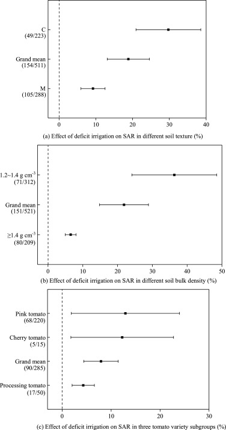

1. [Download : Download high-res image (255KB)](https://ars.els-cdn.com/content/image/1-s2.0-S0378377420309276-gr5_lrg.jpg)
2. [Download : Download full-size image](https://ars.els-cdn.com/content/image/1-s2.0-S0378377420309276-gr5.jpg)

Fig. 5. Effect of deficit irrigation on sugar/acid content ratio (SAR) in different soil texture, soil bulk density and tomato variety groups. Points stand for the mean effect, and bars represent 95% confidence intervals. Numbers in parenthesis in the left column show the number of data pairs (left) and the total number of replicates (right) for each analysis. Soil texture (C = coarse soil, M = medium soil).

### 3.3. Effects of water deficit on tomato VC and carotenoids (lycopene and β-carotene) in different soil textures, soil bulk densities and tomato varieties

VC was improved more by a water deficit in coarse soil than in medium soil, with increase percentages of 18.29% and 15.51%, respectively, as shown in Fig. 6(a). The increase in VC was 0.62% higher (Fig. 6(b)) in soil with 1.2∼1.4 g cm<sup>-3</sup> bulk density (11.85%; 95% CI: 7.37% to 16.52%) than that in soil with ≥ 1.4 g cm<sup>-3</sup> bulk density (11.23%; 95% CI: 8.52% to 14.02%). Though soil texture and bulk density affected the response of VC to water deficit, the 95% confidence intervals overlapped. VC increased the most, by 23.77% (95% CI: 16.57% to 31.42%), in pink tomato, followed by cherry tomato (5.35%, 95% CI: 0.02% to 10.97%) and processing tomato (3.97%, 95% CI: 1.91% to 6.07%). Moreover, the effects of the water deficit in pink tomato were significantly different from those in cherry tomato and processing tomato (Fig. 6(c)).

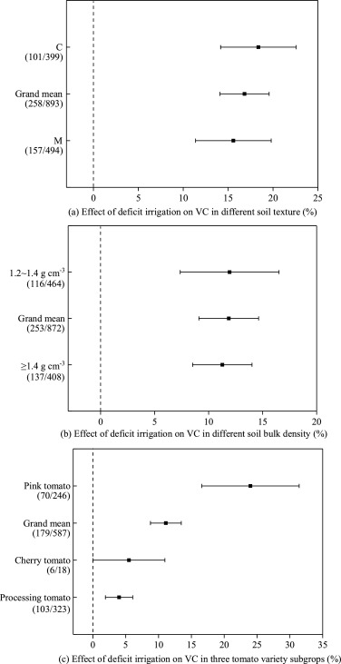

1. [Download : Download high-res image (272KB)](https://ars.els-cdn.com/content/image/1-s2.0-S0378377420309276-gr6_lrg.jpg)
2. [Download : Download full-size image](https://ars.els-cdn.com/content/image/1-s2.0-S0378377420309276-gr6.jpg)

Fig. 6. Effect of deficit irrigation on vitamin C (VC) in different soil texture, soil bulk density and tomato variety groups. Points stand for the mean effect, and bars represent 95% confidence intervals. Numbers in parenthesis in the left column show the number of data pairs (left) and the total number of replicates (right) for each analysis. Soil texture (C = coarse soil, M = medium soil).

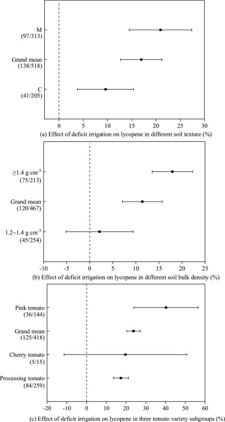

1. [Download : Download high-res image (282KB)](https://ars.els-cdn.com/content/image/1-s2.0-S0378377420309276-gr7_lrg.jpg)
2. [Download : Download full-size image](https://ars.els-cdn.com/content/image/1-s2.0-S0378377420309276-gr7.jpg)

Fig. 7. Effect of deficit irrigation on lycopene in different soil texture, soil bulk density and tomato variety groups. Points stand for the mean effect, and bars represent 95% confidence intervals. Numbers in parenthesis in the left column show the number of data pairs (left) and the total number of replicates (right) for each analysis. Soil texture (C = coarse soil, M = medium soil).

Water deficit had no effects on β-carotene in the processing tomato subgroup (3.24%; CI: -4.87% to 12.04%), while it improved β-carotene in the cherry tomato subgroup by 10.68% (95% CI: 3.04% to 18.88%) as shown in Fig. 8.

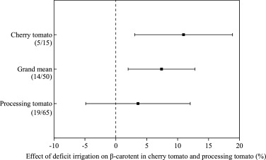

1. [Download : Download high-res image (91KB)](https://ars.els-cdn.com/content/image/1-s2.0-S0378377420309276-gr8_lrg.jpg)
2. [Download : Download full-size image](https://ars.els-cdn.com/content/image/1-s2.0-S0378377420309276-gr8.jpg)

Fig. 8. Effect of deficit irrigation on β-carotene in different tomato variety groups. Points stand for the mean effect, and bars represent 95% confidence intervals. Numbers in parenthesis in the left column show the number of data pairs (left) and the total number of replicates (right) for each analysis.

### 3.4. Effects of water deficit on external tomato quality, including chromatic parameters and shape index in different soil textures, soil bulk densities and tomato varieties

As Fig. 9(a) shows, the color index increased more in coarse soil than in medium soil, by 5.68% and 4.12%, respectively. The effects of water deficit on the color index in soil with a bulk density ≥ 1.4 g cm<sup>-3</sup> were significantly different from those in the other subgroups (Fig. 9(b)). The increased percentages were 9.85% (95% CI: 5.73% to 14.14%) and 3.21% (95% CI: 2.09% to 4.34%) in the two soil bulk density subgroups, respectively. The color index of pink tomato increased the least, and the increase was 2.89% (95% CI: 1.80% to 3.99%) (Fig. 9(c)). The color index increased significantly, by 3.28% (95% CI: 1.84% to 4.75%), in processing tomato.

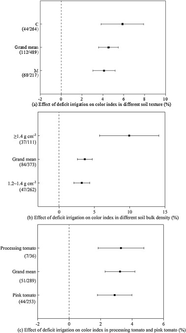

1. [Download : Download high-res image (256KB)](https://ars.els-cdn.com/content/image/1-s2.0-S0378377420309276-gr9_lrg.jpg)
2. [Download : Download full-size image](https://ars.els-cdn.com/content/image/1-s2.0-S0378377420309276-gr9.jpg)

Fig. 9. Effect of deficit irrigation on color index in different soil texture, soil bulk density and tomato variety groups. Points stand for the mean effect, and bars represent 95% confidence intervals. Numbers in parenthesis in the left column show the number of data pairs (left) and the total number of replicates (right) for each analysis. Soil texture (C = coarse soil, M = medium soil).

The effects of water deficit on tomato hue angle in the different tomato variety groups are shown in Fig. 10. There was no statistically significant difference in the change in the hue angle of cherry tomato and processing tomato. Water deficit decreased the hue angle in cherry tomato by 3.11% and that in processing tomato by 3.81%. Due to the insufficient data of hue angle in different soil textures and soil bulk densities, we could not analyze the effects of water deficit on hue angle in these subgroups.

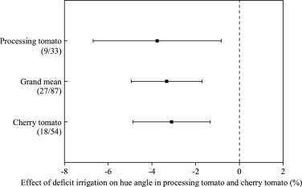

1. [Download : Download high-res image (92KB)](https://ars.els-cdn.com/content/image/1-s2.0-S0378377420309276-gr10_lrg.jpg)
2. [Download : Download full-size image](https://ars.els-cdn.com/content/image/1-s2.0-S0378377420309276-gr10.jpg)

Fig. 10. Effect of deficit irrigation on hue angle in different tomato variety groups. Points stand for the mean effect, and bars represent 95% confidence intervals. Numbers in parenthesis in the left column show the number of data pairs (left) and the total number of replicates (right) for each analysis.

Fig.11 indicates that the soil texture and bulk density significantly affected the response of SI to water deficit. SI increased in coarse soil by 7.30% (95% CI: 4.44% to 10.23%) but did not change in the medium soil (-0.20%; 95% CI: -0.93% to 0.54%), as shown in Fig. 11(a). Similar results for SI are exhibited in Fig. 11(b), with an increase of 8.91% in soil with 1.2∼1.4 g cm<sup>-3</sup> bulk density (95% CI: 6.05% to 11.85%) and no change in soil with ≥ 1.4 g cm<sup>-3</sup> bulk density (-0.56%; 95% CI: -1.49% to 0.37%).

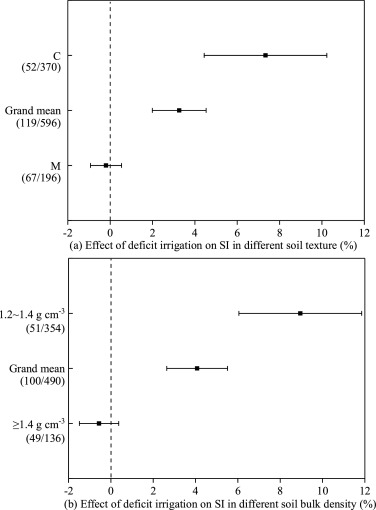

1. [Download : Download high-res image (181KB)](https://ars.els-cdn.com/content/image/1-s2.0-S0378377420309276-gr11_lrg.jpg)
2. [Download : Download full-size image](https://ars.els-cdn.com/content/image/1-s2.0-S0378377420309276-gr11.jpg)

Fig. 11. Effect of deficit irrigation on shape index (SI) in different soil texture and soil bulk density. Points stand for the mean effect, and bars represent 95% confidence intervals. Numbers in parenthesis in the left column show the number of data pairs (left) and the total number of replicates (right) for each analysis. Soil texture (C = coarse soil, M = medium soil).

### 3.5. Effects of water deficit on tomato storage quality in different soil textures, soil bulk densities and tomato varieties

Fig. 12(a) indicates that the soil texture influenced the response of Fn to water deficit. The increase in Fn under water deficit was higher in coarse soil than in medium soil, and it was 9.30% (95% CI: 6.06% to 12.64%) in coarse soil and 3.19% (CI: 1.39% to 5.02%) in medium soil. There was no difference in the Fn response to water deficit among the bulk density subgroups (Fig. 12(b)). Fn increased by 5.59% in soil with ≥ 1.4 g cm<sup>-3</sup> bulk density and 4.97% in soil with 1.2∼1.4 g cm<sup>-3</sup> bulk density. There was no change in the Fn of cherry tomato (95% CI: -2.08% to 9.56%), shown in Fig. 12(c). The Fn of pink tomato increased by 5.54% under water deficit (95% CI: 2.87% to 8.27%), and the Fn of processing tomato increased by 7.89% under water deficit (95% CI: 4.06% to 11.86%).

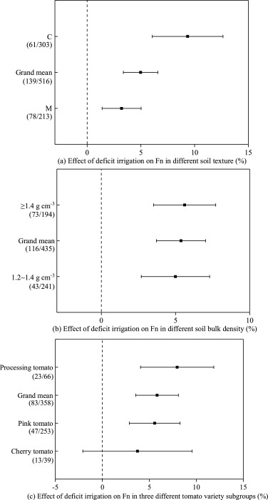

1. [Download : Download high-res image (258KB)](https://ars.els-cdn.com/content/image/1-s2.0-S0378377420309276-gr12_lrg.jpg)
2. [Download : Download full-size image](https://ars.els-cdn.com/content/image/1-s2.0-S0378377420309276-gr12.jpg)

Fig. 12. Effect of deficit irrigation on firmness (Fn) in different soil texture, soil bulk density and tomato variety groups. Points stand for the mean effect, and bars represent 95% confidence intervals. Numbers in parenthesis in the left column show the number of data pairs (left) and the total number of replicates (right) for each analysis. Soil texture (C = coarse soil, M = medium soil).

### 3.6. Effects of water deficit on tomato pH in different soil textures, soil bulk densities and tomato varieties

There was no change in tomato pH under water deficit in coarse soil (95% CI: -0.51% to 1.55%), fine soil (95% CI: -0.38% to 0.58%) or medium soil (95% CI: -0.57% to 0.07%). However, the soil bulk density significantly affected the response of pH to water deficit (Fig. 13(b)). Tomato pH increased by 2.87% (95% CI: 1.47% to 4.29%) in soil with ≥ 1.4 g cm<sup>-3</sup> bulk density but did not change in soil with 1.2∼1.4 g cm<sup>-3</sup> (-0.19%; 95% CI: -0.53% to 0.14%) or <1.2 g cm<sup>-3</sup> bulk density (-0.84%; 95% CI: -1.88% to 0.22%).

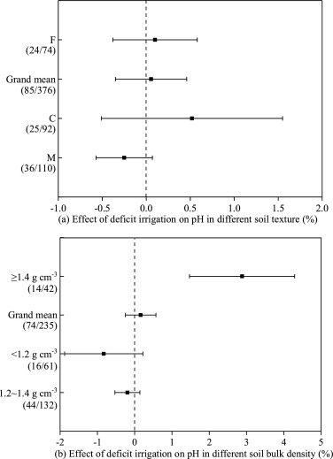

1. [Download : Download high-res image (197KB)](https://ars.els-cdn.com/content/image/1-s2.0-S0378377420309276-gr13_lrg.jpg)
2. [Download : Download full-size image](https://ars.els-cdn.com/content/image/1-s2.0-S0378377420309276-gr13.jpg)

Fig. 13. Effect of deficit irrigation on tomato juice pH in different soil texture and soil bulk density. Points stand for the mean effect, and bars represent 95% confidence intervals. Numbers in parenthesis in the left column show the number of data pairs (left) and the total number of replicates (right) for each analysis. Soil texture (C = coarse soil, F = fine soil, M = medium soil).

## 4. Discussion

### 4.1. Water deficit influence on tomato taste quality variables

Since tomato is known as nutrient-rich, healthy crop that has a high-water demand (Patanè et al., 2011), it is important to determine an effective method to improve tomato quality and save water. Deficit irrigation has been indicated to have beneficial effects on tomato fruit quality with little decrease in yield (Ripoll et al., 2014). As one of the most important tomato fruit quality variables, TSS indicates the proportion (%) of dissolved solids in a solution, which includes approximately 65% sugars (sucrose and hexoses), 13% acids (citrate and malate) and 12% other minor components (phenols, amino acids, soluble pectins, ascorbic acid and minerals) in the tomato fruit pulp (Balibrea et al., 2006; Kader, 2008). In our study, the results demonstrated that deficit irrigation could significantly increase TSS by 12.44%, which was in an agreement with previous studies reporting that soluble solids were higher in deficit treatments than in control treatments (Wang et al. 2015; Patanè and Cosentino, 2010). The reason why tomato obtained higher soluble solids under deficit irrigation was that the decrease of water uptake into tomato led to higher solute concentration (Renquist and Reid, 2001). Fruit taste is mainly determined by the soluble sugar, organic acid and sugar/acid content ratio (Kader, 2008). SS increased significantly, by 11.23%, under water deficit and the same result was obtained by Jiang and Zhao (2019). Mitchell et al. (1991) revealed that increased water stress decreased water uptake in tomato fruit and increased the concentration of solutes in the sap, thus increasing the sugars in the fruit. There was a significant 6.58% increase in OA under deficit irrigation. This finding was supported by Kumar et al. (2015), while there was a decrease in tomato acidity in the study of Jiang and Zhao (2019). This discrepancy may be because tomato acidity depends not only on growth conditions but also on cultural practices and varieties. Previous studies (Shao et al., 2016; Keabetswe et al., 2019) observed an increase in SAR under deficit irrigation, which was similar to our result of an increase of 14.56% in SAR. Achieving the best flavor in tomato requires high sugar concentrations and relatively high acid concentrations (Hao et al., 2019). In our study, under deficit irrigation, both OA and SS were increased and SS was increased more than OA in our study leading to an increase in SAR. This suggests that deficit irrigation may improve tomato flavor.

### 4.2. Water deficit influence on tomato VC and carotenoids (lycopene and β-carotene)

Tomato produces health-giving secondary metabolites such as VC, lycopene and β-carotene (Tohge et al., 2014). These compounds can decrease the death rate of certain cancers and cardiovascular disease (Carr and Frei, 1999). VC increased by 13.84% under deficit irrigation in our study. Many studies indicated that water deficit could increase VC in tomato fruit (Dumas et al., 2003; Patanè et al., 2011; Chen et al., 2014). Water deficit decreased foliage development leading to increasing fruit sunlight exposure, and hence, more VC accumulated (Massot et al., 2010). Lycopene accounts for 80-90% of the total carotenoids (Krumbein et al., 2006) which has anti-carcinogenic and anti-atherogenic potential (Singh and Goyal, 2008; Biddle et al., 2013). Moreover, lycopene increased by 10.46% under water deficit for the same reason as VC (Toor et al., 2006). While both VC and lycopene were significantly increased by deficit irrigation, β-carotene was significantly decreased. The results were contradictory compared with those of Bogale et al. (2016). We analyzed the results of the 6 collected papers deeply and found 21 data pairs from one paper (Schweiggert et al., 2017) with a relative weight of 41.3%. Moreover, most results of this paper showed that water deficit had a significantly negative effect on β-carotene. Considering the publication bias, we calculated the results again excluding this paper, and the effects of deficit irrigation on β-carotene changed and were not significant (-2.00%; CI: -10.00% to 7.00%). The effect of deficit irrigation on β-carotene was not significant in each collected paper, except in the paper of Bogale et al. (2016), because more than one tomato variety was used in some papers. Thus, the response of β-carotene to water deficit needs to be analyzed deeply in future studies. Coyago-Cruz et al. (2017) confirmed that β-carotene was strongly affected by the treatments and the tomato variety.

### 4.3. Water deficit influence on the external quality of tomato, including chromatic parameters and shape index

Lightness decreased by 1.77% under water deficit. This result was the same as that in a previous study (Cantore et al., 2016; Barbagallo et al., 2013). The hue angle decreased by 3.42% under water deficit, which expressed the color intensity (purity). Lower values of lightness and hue angle factually meant fruits darker, redder and more mature (Champa et al., 2015). These results were consistent with results of parameters of a* value and lycopene, and all of these parameters were relevant with a redder tomato. Water deficit had no significant effects on chroma. This may be because the tomato varieties were different among the collected papers, resulting in different responses to water deficit. The a* value is a good parameter for indicating red color development and the degree of ripening in tomato, while the b* parameter shows yellow discoloration (Artés et al., 1999). The value of a* significantly increased, by 11.89%, while the value of b* significantly decreased, by 4.26% under water deficit. This was also reported in previous studies (Pulupol et al., 1996; Zegbe-Domınguez et al., 2003). The increased a* value and decreased b* value increased the color index. As one of the external qualities that are important to consumers, the color index increased by 8.42% under water deficit, consistent with a previous study (Shao et al., 2015). This was because water deficit increased the tomato ethylene content, leading to an increase in lycopene and carotenoid concentrations, thus making the pericarp of the tomato fruit redder (Basiouny et al., 1994). As another important external quality, SI increased by 3.25% under water deficit. The results were the same as those of a previous study reporting that the effects of water deficit on fruit SI were significant in the third bunch of fruits (Hao et al., 2019). Other studies (Shao et al., 2015; Jiang and Zhao, 2019) found that there was a nonsignificant increase in fruit SI compared with that under no water stress.

### 4.4. Water deficit influence on storage quality of tomato

A high Fn value is desirable to both growers and consumers because it allows for a longer storage duration (Shewfelt, 2000). In our study, Fn increased by 12.09%, which was in an agreement with previous results (Patanè and Cosentino, 2010; Chen et al., 2014). The increase in Fn under deficit irrigation may be due to a decrease in internal turgor leading to lower pressure on the cell walls and higher epidermal elasticity (Guichard et al., 2001).

Fn responded to the water deficit significantly differently among soil texture subgroups. Fn was improved by 9.30% and 3.19% in coarse and medium soil, respectively. Although bulk density had no significant effects on Fn, Fn was slightly higher in soil with ≥ 1.4 g cm<sup>-3</sup> bulk density than in soil with 1.2∼1.4 g cm<sup>-3</sup> bulk density, by 0.62%. There was no significant difference in Fn among the three tomato varieties. The Fn of pink tomato and processing tomato significantly increased, by 5.54% and 7.89%, respectively, under deficit irrigation. In contrast, cherry tomato was not significantly influenced by the water deficit. The different responses of Fn to soil and varieties indicated that Fn under water deficit was affected not only by soil properties, but also by environmental factors (e.g., temperature and light intensity). In addition, a previous study reported that Fn was related to the maturity stage (Zheng et al., 2013).

### 4.5. Water deficit influence on tomato pH

Tomato pH is important because it affects the thermal processing conditions applied in industrial tomato processing to produce safe products. In our study, water deficit had no significant effect on pH. This result was consistent with that in previous studies (Tüzel et al., 1994; Hanson et al., 2006). The pH response to water deficit in different soil textures was different from that in soils with different bulk densities. Water deficit had no significant effect on tomato juice pH in coarse, medium and fine soil. However, the tomato pH was significantly increased by deficit irrigation in soil of ≥ 1.4 g cm<sup>-3</sup> bulk density but not in the rest of the bulk density subgroups. The pH response was insignificant in most soil texture and bulk density subgroups because pH depended on cultural practices, growing location, seasonal variations and so on (Favati et al., 2009). For example, a previous study (Garcia and Barrett, 2006) observed that the effect of the growing season on pH was clear.

### 4.6. Limitations of the current study

This study discussed the effects of water deficit on tomato quality considering soil texture, soil bulk density and tomato variety. However, there are other factors, such as the timing and intensity of deficit application, that affect the results (Hou et al., 2020). Moreover, environmental conditions and fertilizers can influence the effects of water deficit on quality. Future research can consider more factors and characterize the effects of their interactions on tomato quality. Moreover, there have been few studies on the effects of water deficit on tomato quality that consider soil properties, such as pH; thus, these aspects could be explored more deeply. For example, Wang et al. (2020) performed a meta-analysis to evaluate how climate affected the response of crop yield to controlled drainage so that the climate could be considered in future studies about the effects of water deficit on tomato quality. Gao et al. (2020) analyzed the effects of biochar application on crop water use efficiency combined with the N application rate.

## 5. Conclusions

Numerous studies have shown that water deficit can improve tomato quality. However, it is known that many factors affect the response of tomato quality to water deficit. Previous studies have addressed the effects of water deficit severity and time on the response of tomato quality to water deficit, but few studies have investigated the effects of soil texture and bulk density on the response of tomato quality to water deficit. Our work provides a quantitative analysis of the current literature available to investigate the effects of water deficit on tomato quality in different soil textures, soil bulk densities and tomato varieties. Overall, water deficit significantly improved most of the quality variables (TSS, SS, OA, SAR, VC, lycopene, color index, a*, SI, Fn), decreased four variables (β-carotene, lightness, hue angle, b*), and had no significant effect on chroma or tomato pH. Deficit irrigation increased TSS, SS, OA, SAR, VC, lycopene, color index, a*, SI and Fn by 12.44%, 11.23%, 6.58%, 14.56%, 13.84%, 10.46%, 8.42%, 11.89%, 3.25% and 12.09%, respectively. Deficit irrigation decreased β-carotene, lightness, hue angle and b* by 11.11%, 1.77%, 3.42% and 4.26%, respectively. Although some quality variables (SAR, SI and Fn) responded significantly differently to water deficit in different soil textures, the rest of the quality variables did not. And most of the quality variables had better values in coarse soil than in medium soil and reached their best values in fine soil. Except for OA, lycopene, color index, Fn and pH, the other quality variables were better in soil of 1.2∼1.4 g cm<sup>-3</sup> bulk density than in soil of ≥ 1.4 g cm<sup>-3</sup> bulk density. Tomato quality showed different responses to water deficit among varieties. For TSS and OA, cherry tomato improved the most, followed by processing tomato and pink tomato. For SS, cherry tomato improved the most, followed by pink tomato and processing tomato. For SAR and VC, pink tomato improved the most, followed by cherry tomato and processing tomato. There was no significant effect on lycopene or Fn in cherry tomato under water deficit, and lycopene was improved more in pink tomato than in processing tomato; Fn showed the opposite result. β-carotene was significantly improved by water deficit in cherry tomato but not in processing tomato. The tomato hue angle responded similarly to water deficit in cherry tomato and processing tomato. The color index, an important tomato color parameter, was improved more in processing tomato than in pink tomato, but the changes in color index in two tomato varieties were not significantly different. The results showed that water deficit can be a potential strategy for improving tomato fruit quality while also saving water. In general, water deficit resulted in redder, firmer and better-tasting tomatoes with more VC and lycopene compared to well-irrigated tomatoes. It would be better to apply deficit irrigation in fine and coarse soil because most of the quality variables were improved more in these soil types than in medium soil. Soil with a bulk density of 1.2∼1.4 g cm<sup>-3</sup> was good for the improvement of taste quality variables, VC and SI but not for the other quality variables. Moreover, cherry tomato had a better response to water deficit than the other two tomato varieties, for four quality variables improved the most in cherry tomato and two other variables also improved.

## Declaration of Competing Interest

No conflict of interest exits in the submission of this manuscript, and manuscript is approved by all authors for publication.

## Acknowledgement

The research was supported by key program granted by the National Nature & Science Foundation of China (No. 51879072) and Postgraduate Research & Practice Innovation Program of Jiangsu Province, and supported by Scientific Research and Practice Innovation Program for Postgraduates in Jiangsu Province (SJKY19_0523), and Jiangsu Qing Lan, and the project of the Young Top-Notch Talent Support Program of National High-level Talents Special Support Plan. The authors extend their gratitude to the editor and anonymous reviewers for substantial comments on earlier versions of this paper.

## References

**Abdel-Razzak et al., 2016**

H. Abdel-Razzak, M. Wahb-Allah, A. Ibrahim, M. Alenazi, A. Alsadon**Response of cherry tomato to irrigation levels and fruit pruning under greenhouse conditions**

J. Agric. Sci. Technol., 18 (4) (2016), pp. 1091-1103

[View Record in Scopus](https://www.scopus.com/inward/record.url?eid=2-s2.0-84977140449&partnerID=10&rel=R3.0.0)Google Scholar

**Adu et al., 2018**

M.O. Adu, D.O. Yawson, F.A. Armah, P.A. Asare, K.A. Frimpong**Meta-analysis of crop yields of full, deficit, and partial root-zone drying irrigation**

Agric. Water Manage., 197 (2018), pp. 79-90

[Article](https://www.sciencedirect.com/science/article/pii/S0378377417303785)[Download PDF](https://www.sciencedirect.com/science/article/pii/S0378377417303785/pdfft?md5=32a93629ba4dbd7947b8449bc0449c2c&pid=1-s2.0-S0378377417303785-main.pdf)[View Record in Scopus](https://www.scopus.com/inward/record.url?eid=2-s2.0-85035796779&partnerID=10&rel=R3.0.0)Google Scholar

**Agbemafle et al., 2014**

R. Agbemafle, J. Owusu-Sekyere, A. Bart-Plange, J. Otchere**Effect of deficit irrigation and storage on physicochemical quality of tomato (*Lycopersicon esculentum* Mill. var. Pechtomech)**

Food Sci. Qual. Manage., 34 (2014), pp. 113-120

[View Record in Scopus](https://www.scopus.com/inward/record.url?eid=2-s2.0-85028256804&partnerID=10&rel=R3.0.0)[Google Scholar](https://scholar.google.com/scholar?q=Effect%20of%20deficit%20irrigation%20and%20storage%20on%20physicochemical%20quality%20of%20tomato)

**Agbna et al., 2017**

G.H.D. Agbna, D.L. She, Z.P. Liu, N.A. Elshaikh, G.C. Shao, L.C. Timm**Effects of deficit irrigation and biochar addition on the growth, yield, and quality of tomato**

Sci. Hortic., 222 (2017), pp. 90-101

[Article](https://www.sciencedirect.com/science/article/pii/S0304423817302790)[Download PDF](https://www.sciencedirect.com/science/article/pii/S0304423817302790/pdfft?md5=39287e6c1b8fe170150711ad262f2db4&pid=1-s2.0-S0304423817302790-main.pdf)[View Record in Scopus](https://www.scopus.com/inward/record.url?eid=2-s2.0-85019114095&partnerID=10&rel=R3.0.0)Google Scholar

**Alameda et al., 2012**

D. Alameda, N.P.R. Anten, R. Villar**Soil compaction effects on growth and root traits of tobacco depend on light, water regime and mechanical stress**

Soil Till. Res., 120 (2012), pp. 121-129

[Article](https://www.sciencedirect.com/science/article/pii/S0167198711002121)[Download PDF](https://www.sciencedirect.com/science/article/pii/S0167198711002121/pdfft?md5=fb03794e7f5289cecbe93b01d61fcf70&pid=1-s2.0-S0167198711002121-main.pdf)[View Record in Scopus](https://www.scopus.com/inward/record.url?eid=2-s2.0-84857137945&partnerID=10&rel=R3.0.0)Google Scholar

**Artés et al., 1999**

F. Artés, M.A. Conesa, S. Hernández, M.I. Gil**Keeping quality of fresh-cut tomato**

Postharvest Biol. Technol., 17 (3) (1999), pp. 153-162

[Article](https://www.sciencedirect.com/science/article/pii/S0925521499000447)[Download PDF](https://www.sciencedirect.com/science/article/pii/S0925521499000447/pdfft?md5=ba53de2541b1c7f6ada2919bbcd5efb1&pid=1-s2.0-S0925521499000447-main.pdf)[View Record in Scopus](https://www.scopus.com/inward/record.url?eid=2-s2.0-0032708526&partnerID=10&rel=R3.0.0)[Google Scholar](https://scholar.google.com/scholar_lookup?title=Keeping%20quality%20of%20fresh-cut%20tomato&publication_year=1999&author=F.%20Art%C3%A9s&author=M.A.%20Conesa&author=S.%20Hern%C3%A1ndez&author=M.I.%20Gil)

**Arthur et al., 2012**

E. Arthur, P. Moldrup, P. Schjønning, L.W. de Jonge**Linking particle and pore size distribution parameters to soil-gas transport properties**

Soil Sci. Soc. Am. J., 76 (1) (2012), pp. 18-27

[CrossRef](https://doi.org/10.2136/sssaj2011.0125)[View Record in Scopus](https://www.scopus.com/inward/record.url?eid=2-s2.0-84855431696&partnerID=10&rel=R3.0.0)Google Scholar

**Bakr et al., 2017**

J. Bakr, H.G. Daood, Z. Pék, L. Helyes, K. Posta**Yield and quality of mycorrhized processing tomato under water scarcity**

Appl. Ecol. Environ. Res., 15 (1) (2017), pp. 401-413

[CrossRef](https://doi.org/10.15666/aeer/1501_401413)[View Record in Scopus](https://www.scopus.com/inward/record.url?eid=2-s2.0-85013167730&partnerID=10&rel=R3.0.0)Google Scholar

**Balibrea et al., 2006**

M.E. Balibrea, C. Martinez-Andujar, J. Cuartero, M.C. Bolarin, F. Perez-Alfocea**The high fruit soluble sugar content in wild Lycopersicon species and their hybrids with cultivars depends on sucrose import during ripening rather than on sucrose metabolism**

Funct. Plant Biol., 33 (3) (2006), pp. 279-288

[View Record in Scopus](https://www.scopus.com/inward/record.url?eid=2-s2.0-33644676946&partnerID=10&rel=R3.0.0)Google Scholar

**Barbagallo et al., 2013**

R.N. Barbagallo, I. Di Silvestrob, C. Patanè**Yield, physicochemical traits, antioxidant pattern, polyphenol oxidase activity and total visual quality of field-grown processing tomato cv. Brigade as affected by water stress in Mediterranean climate**

J. Sci. Food. Agric., 93 (6) (2013), pp. 1449-1457

[CrossRef](https://doi.org/10.1002/jsfa.5913)[View Record in Scopus](https://www.scopus.com/inward/record.url?eid=2-s2.0-84875604551&partnerID=10&rel=R3.0.0)Google Scholar

**Basiouny et al., 1994**

F.M. Basiouny, K. Basiouny, M. Maloney**Influence of water stress on abscisic acid and ethylene production in tomato under different PAR levels**

J. Hortic. Sci. Biotech., 69 (3) (1994), pp. 535-541

[CrossRef](https://doi.org/10.1080/14620316.1994.11516485)[View Record in Scopus](https://www.scopus.com/inward/record.url?eid=2-s2.0-0027953256&partnerID=10&rel=R3.0.0)Google Scholar

**Battilani et al., 2012**

A. Battilani, M.H. Prieto, C. Argerich, C. Campillo, V. Cantore**Tomato**

P. Steduto, T.C. Hasiao, E. Fereres, D. Rase (Eds.), Crop Yield Response to Water, FAO. Irrigation and Drainage, Rome (2012), p. 530

[Google Scholar](https://scholar.google.com/scholar_lookup?title=Tomato&publication_year=2012&author=A.%20Battilani&author=M.H.%20Prieto&author=C.%20Argerich&author=C.%20Campillo&author=V.%20Cantore)

**Bengough et al., 2006**

A.G. Bengough, M.F. Bransby, J. Hans, S.J. McKenna, T.J. Roberts, T.A. Valentine**Root responses to soil physical conditions: growth dynamics from field to cell**

J. Exp. Bot., 57 (2006), pp. 437-447

[CrossRef](https://doi.org/10.1093/jxb/erj003)[View Record in Scopus](https://www.scopus.com/inward/record.url?eid=2-s2.0-30344478547&partnerID=10&rel=R3.0.0)Google Scholar

**Bertin et al., 2000**

N. Bertin, S. Guichard, C. Leonardi, J.J. Longuenesse, D. Langlois, B. Navez**Seasonal evolution of the quality of fresh glasshouse tomatoes under Mediterranean conditions, as affected by air vapour pressure deficit and plant fruit load**

Ann Bot., 85 (6) (2000), pp. 741-750

[Article](https://www.sciencedirect.com/science/article/pii/S0305736400911235)[Download PDF](https://www.sciencedirect.com/science/article/pii/S0305736400911235/pdf?md5=d2a9807353742f6fb254a1d303d3a633&pid=1-s2.0-S0305736400911235-main.pdf)[View Record in Scopus](https://www.scopus.com/inward/record.url?eid=2-s2.0-0033827352&partnerID=10&rel=R3.0.0)Google Scholar

**Biddle et al., 2013**

M. Biddle, D. Moser, E.K. Song, S. Heo, H. Payne-Emerson, S.B. Dunbar, S. Pressler, T. Lennie**Higher dietary lycopene intake is associated with longer cardiac event-free survival in patients with heart failure**

Eur. J. Cardiovasc. Nurs., 12 (4) (2013), pp. 377-384

[CrossRef](https://doi.org/10.1177/1474515112459601)[View Record in Scopus](https://www.scopus.com/inward/record.url?eid=2-s2.0-84880884087&partnerID=10&rel=R3.0.0)Google Scholar

**Birhanu and Tilahun, 2010**

K. Birhanu, K. Tilahun**Fruit yield and quality of drip-irrigated tomato under deficit irrigation**

Afr. J. Food Agric. Nutr. Dev., 10 (2) (2010), pp. 2139-2151

[View Record in Scopus](https://www.scopus.com/inward/record.url?eid=2-s2.0-84893047888&partnerID=10&rel=R3.0.0)[Google Scholar](https://scholar.google.com/scholar_lookup?title=Fruit%20yield%20and%20quality%20of%20drip-irrigated%20tomato%20under%20deficit%20irrigation&publication_year=2010&author=K.%20Birhanu&author=K.%20Tilahun)

**Bogale et al., 2016**

A. Bogale, M. Nagle, S. Latif, M. Aguila, J. Müller**Regulated deficit irrigation and partial root-zone drying irrigation impact bioactive compounds and antioxidant activity in two select tomato cultivars**

Sci. Hortic., 213 (2016), pp. 115-124

[Article](https://www.sciencedirect.com/science/article/pii/S0304423816305313)[Download PDF](https://www.sciencedirect.com/science/article/pii/S0304423816305313/pdfft?md5=63b5684dcf44726f01f4ee833c4152ff&pid=1-s2.0-S0304423816305313-main.pdf)[View Record in Scopus](https://www.scopus.com/inward/record.url?eid=2-s2.0-84992398776&partnerID=10&rel=R3.0.0)Google Scholar

**Cantore et al., 2016**

V. Cantore, O. Lechkar, E. Karabulut, M.H. Sellami, R. Albrizio, F. Boari, A.M. Stellacci, M. Todorovic**Combined effect of deficit irrigation and strobilurin application on yield, fruit quality and water use efficiency of “cherry” tomato (*Solanum lycopersicum* L.)**

Agric. Water Manage., 167 (2016), pp. 53-61

[Article](https://www.sciencedirect.com/science/article/pii/S0378377415301955)[Download PDF](https://www.sciencedirect.com/science/article/pii/S0378377415301955/pdfft?md5=c4889c53b09f1a697d61785ef9e2ea6f&pid=1-s2.0-S0378377415301955-main.pdf)[View Record in Scopus](https://www.scopus.com/inward/record.url?eid=2-s2.0-84954113918&partnerID=10&rel=R3.0.0)[Google Scholar](https://scholar.google.com/scholar?q=Combined%20effect%20of%20deficit%20irrigation%20and%20strobilurin%20application%20on%20yield,%20fruit%20quality%20and%20water%20use%20efficiency%20of%20cherry%20tomato)

**Cao et al., 2005**

S.B. Cao, S.C. Chen, Z.J. Li**Effect of soil conditioner on yield and quality of tomato in greenhouse**

Shandong Agric. Sci., 3 (2005), pp. 59-63

(in Chinese, with English summary)

[View Record in Scopus](https://www.scopus.com/inward/record.url?eid=2-s2.0-85089427753&partnerID=10&rel=R3.0.0)Google Scholar

**Carr and Frei, 1999**

A.C. Carr, B. Frei**Toward a new recommended dietary allowance for vitamin C based on antioxidant and health effects in humans**

Am. J. Clin. Nutr., 69 (6) (1999), pp. 1086-1107

[CrossRef](https://doi.org/10.1093/ajcn/69.6.1086)[View Record in Scopus](https://www.scopus.com/inward/record.url?eid=2-s2.0-0032977279&partnerID=10&rel=R3.0.0)Google Scholar

**Casa and Rouphael, 2014**

R. Casa, Y. Rouphael**Effects of partial root-zone drying irrigation on yield, fruit quality, and water-use efficiency in processing tomato**

J. Hortic. Sci. Biotech., 89 (4) (2014), pp. 389-396

[CrossRef](https://doi.org/10.1080/14620316.2014.11513097)[View Record in Scopus](https://www.scopus.com/inward/record.url?eid=2-s2.0-84903761560&partnerID=10&rel=R3.0.0)Google Scholar

**Chai et al., 2016**

Q. Chai, Y.T. Gan, C. Zhao, H.L. Xu, R.M. Waskom, Y.N. Niu, K.H.M. Siddique**Regulated deficit irrigation for crop production under drought stress. A review**

Agron. Sustain. Dev., 36 (2016), p. 3

[View Record in Scopus](https://www.scopus.com/inward/record.url?eid=2-s2.0-85070484328&partnerID=10&rel=R3.0.0)Google Scholar

**Champa et al., 2015**

W.A.H. Champa, M.I.S. Gill, B.V.C. Mahajan, N.K. Arora**Preharvest salicylic acid treatments to improve quality and postharvest life of table grapes (Vitis vinifera L.) cv. flame seedless**

J. Food Sci. Technol-Myscore., 52 (6) (2015), pp. 3607-3616

[View Record in Scopus](https://www.scopus.com/inward/record.url?eid=2-s2.0-84929964997&partnerID=10&rel=R3.0.0)[Google Scholar](https://scholar.google.com/scholar?q=Preharvest%20salicylic%20acid%20treatments%20to%20improve%20quality%20and%20postharvest%20life%20of%20table%20grapes%20%20cv.%20flame%20seedless)

**Chen, 2006**

X.X. Chen**Study on the effects of soil moisture on catsup tomato’s yield formation and quality**

(D, in Chinese, with English summary)

(2006)

[Google Scholar](https://scholar.google.com/scholar?q=Study%20on%20the%20effects%20of%20soil%20moisture%20on%20catsup%20tomatos%20yield%20formation%20and%20quality)

**Chen et al., 2014**

J.L. Chen, S.Z. Kang, T.S. Du, P. Guo, R.J. Qiu, R.Q. Chen, F. Gu**Modeling relations of tomato yield and fruit quality with water deficit at different growth stages under greenhouse condition**

Agric. Water Manage., 146 (2014), pp. 131-148

[Article](https://www.sciencedirect.com/science/article/pii/S037837741400225X)[Download PDF](https://www.sciencedirect.com/science/article/pii/S037837741400225X/pdfft?md5=625249b2972d6e848334f8e14d55905f&pid=1-s2.0-S037837741400225X-main.pdf)[View Record in Scopus](https://www.scopus.com/inward/record.url?eid=2-s2.0-84906048742&partnerID=10&rel=R3.0.0)Google Scholar

**Colla et al., 1999**

G. Colla, R. Casa, B. Lo Cascio, F. Saccardo, O. Temperini, C. Leoni**Responses of processing tomato to water regime and fertilization in central Italy**

Acta Hortic., 487 (1999), pp. 531-535

[View Record in Scopus](https://www.scopus.com/inward/record.url?eid=2-s2.0-78651350017&partnerID=10&rel=R3.0.0)Google Scholar

**Coyago-Cruz et al., 2017**

E. Coyago-Cruz, M. Corell, C.M. Stinco, D. Hernanz, A. Moriana, A.J. Meléndez-Martínez**Effect of regulated de fi cit irrigation on quality parameters, carotenoids and phenolics of diverse tomato varieties (*Solanum lycopersicum* L.)**

Food Res. Int., 96 (2017), pp. 72-83

[Article](https://www.sciencedirect.com/science/article/pii/S0963996917301163)[Download PDF](https://www.sciencedirect.com/science/article/pii/S0963996917301163/pdfft?md5=e162c915bdca15d5029a9a6abecbff4b&pid=1-s2.0-S0963996917301163-main.pdf)[View Record in Scopus](https://www.scopus.com/inward/record.url?eid=2-s2.0-85015357575&partnerID=10&rel=R3.0.0)[Google Scholar](https://scholar.google.com/scholar?q=Effect%20of%20regulated%20de%20fi%20cit%20irrigation%20on%20quality%20parameters,%20carotenoids%20and%20phenolics%20of%20diverse%20tomato%20varieties)

**Coyago-Cruz et al., 2019**

E. Coyago-Cruz, A.J. Meléndez-martínez, A. Moriana, I.F. Girón, M.J. Martín-Palomo, A. Galindo, D. Pérez-López, A. Torrecillas, E. Beltran-Sinchiguano, M. Corell**Yield response to regulated deficit irrigation of greenhouse cherry tomatoes**

Agric. Water Manage., 213 (2019), pp. 212-221

[Article](https://www.sciencedirect.com/science/article/pii/S0378377418307972)[Download PDF](https://www.sciencedirect.com/science/article/pii/S0378377418307972/pdfft?md5=aa3547106403e640cdddfdaa885c1307&pid=1-s2.0-S0378377418307972-main.pdf)[View Record in Scopus](https://www.scopus.com/inward/record.url?eid=2-s2.0-85055468762&partnerID=10&rel=R3.0.0)Google Scholar

**Davies and Hobson, 1981**

J.N. Davies, G.E. Hobson**The constituents of tomato fruit; the influence of environment, nutrition and genotype**

Crit. Rev. Food Sci. Nutr., 15 (3) (1981), pp. 205-280

[CrossRef](https://doi.org/10.1080/10408398109527317)[View Record in Scopus](https://www.scopus.com/inward/record.url?eid=2-s2.0-0019751236&partnerID=10&rel=R3.0.0)Google Scholar

**Djurović et al., 2016**

N. Djurović, M. Ćosíć, R. Stričević, S. Savić, M. Domazet**Effect of irrigation regime and application of kaolin on yield, quality and water use efficiency of tomato**

Sci. Hortic., 201 (2016), pp. 271-278

[Article](https://www.sciencedirect.com/science/article/pii/S0304423816300607)[Download PDF](https://www.sciencedirect.com/science/article/pii/S0304423816300607/pdfft?md5=9017102c6ebee241e7d788abf57d733b&pid=1-s2.0-S0304423816300607-main.pdf)[View Record in Scopus](https://www.scopus.com/inward/record.url?eid=2-s2.0-84957698970&partnerID=10&rel=R3.0.0)Google Scholar

**Dorais et al., 2008**

M. Dorais, D.L. Ehret, A.P. Papadopoulos**Tomato (Solanum lycopersicum) health components from the seed to the consumer**

Phytochem. Rev., 7 (2008), pp. 231-250

[CrossRef](https://doi.org/10.1007/s11101-007-9085-x)[View Record in Scopus](https://www.scopus.com/inward/record.url?eid=2-s2.0-43049174572&partnerID=10&rel=R3.0.0)[Google Scholar](https://scholar.google.com/scholar?q=Tomato%20%20health%20components%20from%20the%20seed%20to%20the%20consumer)

**Du et al., 2017**

Y.D. Du, H.X. Cao, S.Q. Liu, X.B. Gu, Y.X. Cao**Response of yield, quality, water and nitrogen use efficiency of tomato to different levels of water and nitrogen under drip irrigation in Northwestern China**

J. Integr. Agric., 16 (5) (2017), pp. 1153-1161

[Article](https://www.sciencedirect.com/science/article/pii/S2095311916613710)[Download PDF](https://www.sciencedirect.com/science/article/pii/S2095311916613710/pdf?md5=3f5527273037daa6f7705d81ceb6c007&pid=1-s2.0-S2095311916613710-main.pdf)[View Record in Scopus](https://www.scopus.com/inward/record.url?eid=2-s2.0-85019046829&partnerID=10&rel=R3.0.0)Google Scholar

**Dumas et al., 2003**

Y. Dumas, M. Dadomo, G. Di Lucca, P. Grolier**Effects of environmental factors and agricultural techniques on antioxidant content of tomatoes**

J. Sci. Food Agric., 83 (5) (2003), pp. 369-382

[View Record in Scopus](https://www.scopus.com/inward/record.url?eid=2-s2.0-0037380584&partnerID=10&rel=R3.0.0)Google Scholar

**FAOSTAT, 2018**

FAOSTAT**Food and Agricultural Organisation of the United Nations**

Rome

(2018)

[Google Scholar](https://scholar.google.com/scholar_lookup?title=Food%20and%20Agricultural%20Organisation%20of%20the%20United%20Nations&publication_year=2018&author=FAOSTAT)

**Favati et al., 2009**

F. Favati, S. Lovelli, F. Galgano, V. Miccolis, T. Di Tommaso, V. Candido**Processing tomato quality as affected by irrigation scheduling**

Sci. Hortic., 122 (4) (2009), pp. 562-571

[Article](https://www.sciencedirect.com/science/article/pii/S0304423809003203)[Download PDF](https://www.sciencedirect.com/science/article/pii/S0304423809003203/pdfft?md5=ca1e3d68efcb6fff249717ab9a0a08b0&pid=1-s2.0-S0304423809003203-main.pdf)[View Record in Scopus](https://www.scopus.com/inward/record.url?eid=2-s2.0-69249221460&partnerID=10&rel=R3.0.0)Google Scholar

**Fullana-pericàs et al., 2019**

M. Fullana-pericàs, M.À. Conesa, C. Douthe, H.El. Aou-ouad, M. Ribas-carbó**Tomato landraces as a source to minimize yield losses and improve fruit quality under water deficit conditions**

Agric. Water Manage., 223 (2019), Article 105722

[Article](https://www.sciencedirect.com/science/article/pii/S0378377419300514)[Download PDF](https://www.sciencedirect.com/science/article/pii/S0378377419300514/pdfft?md5=d92481b3b76aa25b13b5f019abadc66d&pid=1-s2.0-S0378377419300514-main.pdf)Google Scholar

**Gao, 2006**

F.S. Gao**Effect of soil water on growth development and some physiological characteristics in tomato**

(D, in Chinese, with English summary)

(2006)

[Google Scholar](https://scholar.google.com/scholar_lookup?title=Effect%20of%20soil%20water%20on%20growth%20development%20and%20some%20physiological%20characteristics%20in%20tomato&publication_year=2006&author=F.S.%20Gao)

**Gao et al., 2020**

Y. Gao, G.C. Shao, J. Lu, K. Zhang, S.Q. Wu, Z.Y. Wang**Effects of biochar application on crop water use efficiency depend on experimental conditions: A meta-analysis**

Field Crop. Res., 249 (2020), Article 107763

[Article](https://www.sciencedirect.com/science/article/pii/S0378429019315801)[Download PDF](https://www.sciencedirect.com/science/article/pii/S0378429019315801/pdfft?md5=e9339c15e590ce1c2bdb9ebf9eb8292f&pid=1-s2.0-S0378429019315801-main.pdf)Google Scholar

**Giuliani et al., 2016**

M.M. Giuliani, G. Gatta, E. Nardella, E. Tarantino**Water saving strategies assessment on processing tomato cultivated in Mediterranean region**

Ital. J. Agron., 11 (11) (2016), pp. 69-76

[CrossRef](https://doi.org/10.4081/ija.2016.738)[View Record in Scopus](https://www.scopus.com/inward/record.url?eid=2-s2.0-84961671457&partnerID=10&rel=R3.0.0)Google Scholar

**Giuliani et al., 2017**

M.M. Giuliani, E. Nardella, A. Gagliardi, G. Gatta**Deficit irrigation and partial root-zone drying techniques in processing tomato cultivated under mediterranean climate conditions**

Sustain. -Basel., 9 (12) (2017), p. 2197

[CrossRef](https://doi.org/10.3390/su9122197)Google Scholar

**Garcia and Barrett, 2006**

E. Garcia, D.M. Barrett**Evaluation of processing tomatoes from twoconsecutive growing seasons: quality attributes, peel ability and yield**

J. Food Process Preserv., 30 (2006), pp. 20-36

[CrossRef](https://doi.org/10.1111/j.1745-4549.2005.00044.x)[View Record in Scopus](https://www.scopus.com/inward/record.url?eid=2-s2.0-33645116126&partnerID=10&rel=R3.0.0)Google Scholar

**Giuliani et al., 2019**

M.M. Giuliani, A. Gagliardi, E. Nardella, F. Carucci, M.L. Amodio, G. Gatta**The effect of strobilurin on ethylene production in flowers, yield and quality parameters of processing tomato grown under a moderate water stress condition in Mediterranean area**

Sci. Hortic., 249 (2019), pp. 155-161

[Article](https://www.sciencedirect.com/science/article/pii/S0304423819300585)[Download PDF](https://www.sciencedirect.com/science/article/pii/S0304423819300585/pdfft?md5=e02a6cc5bb40dfb9a3be1204f9c116ed&pid=1-s2.0-S0304423819300585-main.pdf)[View Record in Scopus](https://www.scopus.com/inward/record.url?eid=2-s2.0-85060750754&partnerID=10&rel=R3.0.0)Google Scholar

**Gong et al., 2016**

X.W. Gong, H. Liu, J.S. Sun, H. Zhang, X.L. Wu, X.G. Chen, H.M. Wang**Effects of regulated deficit irrigation on solar greenhouse tomato growth, yield and quality**

Water Saving Irri. (9) (2016), pp. 52-56

(in Chinese, with English summary)

[View Record in Scopus](https://www.scopus.com/inward/record.url?eid=2-s2.0-85030759492&partnerID=10&rel=R3.0.0)Google Scholar

**Gong et al., 2017**

X.W. Gong, H. Liu, D.X. Liu, W.W. Wang, J.S. Sun**Fuzzy comprehensive evaluation on regulated deficit irrigation scheduling of tomato drip irrigated in solar greenhouse**

Trans. Chin. Soc. Agric. Eng., 33 (14) (2017), pp. 144-151

(in Chinese, with English summary)

[View Record in Scopus](https://www.scopus.com/inward/record.url?eid=2-s2.0-85030750444&partnerID=10&rel=R3.0.0)Google Scholar

**Guichard et al., 2001**

S. Guichard, N. Bertin, C. Leonardi, C. Gary**Tomato fruit quality in relation to water and carbon fluxes**

Agronomie, 21 (4) (2001), pp. 385-392

[View Record in Scopus](https://www.scopus.com/inward/record.url?eid=2-s2.0-0034964549&partnerID=10&rel=R3.0.0)Google Scholar

**Guida et al., 2017**

G. Guida, M.H. Sellami, C. Mistretta, M. Oliva, R. Buonomo, R. De Mascellis, C. Patanè, Y. Rouphael, R. Albrizio, P. Giorio**Agronomical, physiological and fruit quality responses of two Italian long-storage tomato landraces under rain-fed and full irrigation conditions**

Agric. Water Manage., 180 (2017), pp. 126-135

[Article](https://www.sciencedirect.com/science/article/pii/S0378377416304474)[Download PDF](https://www.sciencedirect.com/science/article/pii/S0378377416304474/pdfft?md5=e307a6e6f2d22da0f16da860ec504a1c&pid=1-s2.0-S0378377416304474-main.pdf)[View Record in Scopus](https://www.scopus.com/inward/record.url?eid=2-s2.0-84995792511&partnerID=10&rel=R3.0.0)Google Scholar

**Guo et al., 2014**

Y.H. Guo, K. Zhang, Y.Z. Chen, G.J. Han, N.L. Chen**Effects of water and nitrogen coupling on the fruit yield and quality of*Lycopersicon esculentum* in the middle reaches of the Heihe River**

J. Gansu Agric. Uni., 49 (2014), pp. 65-69

(in Chinese, with English summary)

[View Record in Scopus](https://www.scopus.com/inward/record.url?eid=2-s2.0-85089411243&partnerID=10&rel=R3.0.0)Google Scholar

**Guo et al., 2007**

H.T. Guo, Z.R. Zou, X.J. Yang, H.F. Zhou**Effects of regulated deficit irrigation (RDI) on physiological indexes, yield, quality and WUE of tomato**

Agric. Research Arid Areas, 25 (3) (2007), pp. 133-137

(in Chinese, with English summary)

[View Record in Scopus](https://www.scopus.com/inward/record.url?eid=2-s2.0-84874844604&partnerID=10&rel=R3.0.0)[Google Scholar](https://scholar.google.com/scholar?q=Effects%20of%20regulated%20deficit%20irrigation%20%20on%20physiological%20indexes,%20yield,%20quality%20and%20WUE%20of%20tomato)

**Guo, 2007**

H.T. Guo**Effect of RDI on physiology characters and yield quality of tomato**

(D, in Chinese, with English summary)

(2007)

[Google Scholar](https://scholar.google.com/scholar_lookup?title=Effect%20of%20RDI%20on%20physiology%20characters%20and%20yield%20quality%20of%20tomato&publication_year=2007&author=H.T.%20Guo)

**Hamza and Anderson, 2005**

M.A. Hamza, W.K. Anderson**Soil compaction in cropping systems - a review of the nature, causes and possible solutions**

Soil Tillage Res., 82 (2005), pp. 121-145

[Article](https://www.sciencedirect.com/science/article/pii/S0167198704001849)[Download PDF](https://www.sciencedirect.com/science/article/pii/S0167198704001849/pdfft?md5=ac4911f19ebd1ec9a6d715755d4e31b1&pid=1-s2.0-S0167198704001849-main.pdf)[View Record in Scopus](https://www.scopus.com/inward/record.url?eid=2-s2.0-18144366279&partnerID=10&rel=R3.0.0)Google Scholar

**Hanson et al., 2006**

B.R. Hanson, R.B. Hutmacher, D.M. May**Drip irrigation of tomato and cotton under shallow saline ground water conditions**

Irrig. Drain. Sys., 20 (2006), pp. 155-175

[CrossRef](https://doi.org/10.1007/s10795-005-9000-9)[View Record in Scopus](https://www.scopus.com/inward/record.url?eid=2-s2.0-33747015222&partnerID=10&rel=R3.0.0)Google Scholar

**Hao et al., 2019**

S.X. Hao, H.X. Cao, H.B. Wang, X.Y. Pan**Effects of water stress at different growth stages on comprehensive fruit quality and yield in different bunches of tomatoes in greenhouses**

Int. J. Agric. Biol. Eng., 12 (3) (2019), pp. 67-76

[CrossRef](https://doi.org/10.25165/j.ijabe.20191203.4468)[View Record in Scopus](https://www.scopus.com/inward/record.url?eid=2-s2.0-85067970259&partnerID=10&rel=R3.0.0)Google Scholar

**Hartz et al., 2006**

T.K. Hartz, P.R. Johnstone, M. Le Strang**Late-season deficit irrigation is a reliable tool for soluble solids improvement in drip-irrigated processing tomato production**

Acta. Hort., 724 (2006), pp. 61-65

[CrossRef](https://doi.org/10.17660/ActaHortic.2006.724.6)[View Record in Scopus](https://www.scopus.com/inward/record.url?eid=2-s2.0-33846491768&partnerID=10&rel=R3.0.0)Google Scholar

**Higgins et al., 2003**

J.P.T. Higgins, S.G. Thompson, J.J. Deeks, D.G. Altman**Measuring inconsistency in meta-analyses**

BMJ., 327 (2003), pp. 557-560

[CrossRef](https://doi.org/10.1136/bmj.327.7414.557)[View Record in Scopus](https://www.scopus.com/inward/record.url?eid=2-s2.0-0041876133&partnerID=10&rel=R3.0.0)[Google Scholar](https://scholar.google.com/scholar_lookup?title=Measuring%20inconsistency%20in%20meta-analyses&publication_year=2003&author=J.P.T.%20Higgins&author=S.G.%20Thompson&author=J.J.%20Deeks&author=D.G.%20Altman)

**Hedges et al., 1999**

L.V. Hedges, J. Gurevitch, P.S. Curtis**The meta-analysis of response ratios in experimental ecology**

Ecology, 80 (4) (1999), pp. 1150-1156

[View Record in Scopus](https://www.scopus.com/inward/record.url?eid=2-s2.0-0033037138&partnerID=10&rel=R3.0.0)[Google Scholar](https://scholar.google.com/scholar_lookup?title=The%20meta-analysis%20of%20response%20ratios%20in%20experimental%20ecology&publication_year=1999&author=L.V.%20Hedges&author=J.%20Gurevitch&author=P.S.%20Curtis)

**Helyes et al., 2006**

L. Helyes, Z. Pék, A. Lugasi**Tomato fruit quality and content depend on stage of maturity**

Hortscience, 41 (6) (2006), pp. 1400-1401

[CrossRef](https://doi.org/10.21273/hortsci.41.6.1400)[View Record in Scopus](https://www.scopus.com/inward/record.url?eid=2-s2.0-33749261984&partnerID=10&rel=R3.0.0)[Google Scholar](https://scholar.google.com/scholar_lookup?title=Tomato%20fruit%20quality%20and%20content%20depend%20on%20stage%20of%20maturity&publication_year=2006&author=L.%20Helyes&author=Z.%20P%C3%A9k&author=A.%20Lugasi)

**Hou et al., 2020**

X.M. Hou, W.D. Zhang, T.S. Du, S.Z. Kang, W.J. Davies**Responses of water accumulation and solute metabolism in tomato fruit to water scarcity and implications for main fruit quality variables**

J. Exp. Bot., 71 (4) (2020), pp. 1249-1264

[CrossRef](https://doi.org/10.1093/jxb/erz526)[View Record in Scopus](https://www.scopus.com/inward/record.url?eid=2-s2.0-85080845896&partnerID=10&rel=R3.0.0)Google Scholar

**Horchani et al., 2008**

F. Horchani, P. Gallusci, P. Baldet, C. Cabasson, M. Maucourt, D. Rolin, S. Aschi-Smiti, P. Raymond**Prolonged root hypoxia induces ammonium accumulation and decreases the nutritional quality of tomato fruits**

J. Plant Physiol., 165 (2008), pp. 1352-1359

[Article](https://www.sciencedirect.com/science/article/pii/S0176161707003185)[Download PDF](https://www.sciencedirect.com/science/article/pii/S0176161707003185/pdfft?md5=1861eaf4853548948b9f74bf28a8671e&pid=1-s2.0-S0176161707003185-main.pdf)[View Record in Scopus](https://www.scopus.com/inward/record.url?eid=2-s2.0-49049122244&partnerID=10&rel=R3.0.0)Google Scholar

**Intelmann et al., 2005**

D. Intelmann, D. Jaros, H. Rohm**Identification of color optima of commercial tomato catsup**

Eur. Food Res. and Technol., 221 (2005), pp. 662-666

[CrossRef](https://doi.org/10.1007/s00217-005-0048-4)[View Record in Scopus](https://www.scopus.com/inward/record.url?eid=2-s2.0-27844606936&partnerID=10&rel=R3.0.0)[Google Scholar](https://scholar.google.com/scholar_lookup?title=Identification%20of%20color%20optima%20of%20commercial%20tomato%20catsup&publication_year=2005&author=D.%20Intelmann&author=D.%20Jaros&author=H.%20Rohm)

**IPCC, 2014**

IPCC**Climate Change 2014: Synthesis Report**

Core Writing Team, R.K. Pachauri, L.A. Meyer (Eds.), Contribution of Working Groups Ⅰ, Ⅱ, and Ⅲ to Fifth Assessment Report of the Intergovernmental Panel on Climate Change, IPCC, Geneva, Switzerland (2014), p. 151

[View Record in Scopus](https://www.scopus.com/inward/record.url?eid=2-s2.0-85008890505&partnerID=10&rel=R3.0.0)[Google Scholar](https://scholar.google.com/scholar_lookup?title=Climate%20Change%202014%3A%20Synthesis%20Report&publication_year=2014&author=IPCC)

**Jeffery et al., 2017**

S. Jeffery, D. Abalos, M. Prodana, A.C. Bastos, J.W. van Groenigen, B.A. Hungate, F. Verheijen**Biochars boosts tropical but not temperate crop yields**

Environ. Res. Lett., 12 (2017), Article 053001

[CrossRef](https://doi.org/10.1088/1748-9326/aa67bd)Google Scholar

**Jian et al., 2016**

S.Y. Jian, J.W. Li, J. Chen, G.S. Wang, M.A. Mayes, K.E. Dzantor, D.F. Hui, Y.Q. Luo**Soil extracellular enzyme activities, soil carbon and nitrogen storage under nitrogen fertilization: A meta-analysis**

Soil Biol. Biochem., 101 (2016), pp. 32-43

[Article](https://www.sciencedirect.com/science/article/pii/S0038071716301389)[Download PDF](https://www.sciencedirect.com/science/article/pii/S0038071716301389/pdfft?md5=7e8867073ef69f180dc6106b174ac4a8&pid=1-s2.0-S0038071716301389-main.pdf)[View Record in Scopus](https://www.scopus.com/inward/record.url?eid=2-s2.0-84977619295&partnerID=10&rel=R3.0.0)Google Scholar

**Jiang et al., 2009**

F.C. Jiang, M.Y. Liu, Y.Z. Qiao, L. Shi, B.D. Dong**Effects of deficit irrigation and Zn on yield, quality and WUE of tomato**

Agric. Research Arid Areas, 27 (3) (2009), pp. 60-65

(in Chinese with English summary)

[View Record in Scopus](https://www.scopus.com/inward/record.url?eid=2-s2.0-85086798363&partnerID=10&rel=R3.0.0)Google Scholar

**Jiang and Zhao, 2019**

X.L. Jiang, Y.L. Zhao**Quantitative Analysis of Tomato Yield and Comprehensive Fruit Quality in Response to Deficit Irrigation at Different Growth Stages**

Hortscience, 54 (8) (2019), pp. 1409-1417

[CrossRef](https://doi.org/10.21273/hortsci14180-19)[View Record in Scopus](https://www.scopus.com/inward/record.url?eid=2-s2.0-85072059954&partnerID=10&rel=R3.0.0)Google Scholar

**Johnstone et al., 2005**

P.R. Johnstone, T.K. Hartz, M. LeStrange, J.J. Nunez, E.M. Miyao**Managing Fruit Soluble Solids with Late-season Deficit Irrigation in Drip-irrigated Processing Tomato Production**

Hortscience, 40 (6) (2005), pp. 1857-1861

[CrossRef](https://doi.org/10.21273/hortsci.40.6.1857)[View Record in Scopus](https://www.scopus.com/inward/record.url?eid=2-s2.0-24944468193&partnerID=10&rel=R3.0.0)Google Scholar

**Kader, 2008**

A.A. Kader**Flavor quality of fruits and vegetables**

J. Sci. Food Agric., 88 (2008), pp. 1863-1868

[CrossRef](https://doi.org/10.1002/jsfa.3293)[View Record in Scopus](https://www.scopus.com/inward/record.url?eid=2-s2.0-49749130070&partnerID=10&rel=R3.0.0)[Google Scholar](https://scholar.google.com/scholar_lookup?title=Flavor%20quality%20of%20fruits%20and%20vegetables&publication_year=2008&author=A.A.%20Kader)

**Kang et al., 2017**

S.Z. Kang, X.M. Hao, T.S. Du, L. Tong, X.L. Su, H.N. Lu, X.L. Li, Z.L. Huo, S.E. Li, R.S. Ding**Improving agricultural water productivity to ensure food security in China under changing environment: From research to practice**

Agric. Water Manage., 179 (2017), pp. 5-17

[Article](https://www.sciencedirect.com/science/article/pii/S037837741630169X)[Download PDF](https://www.sciencedirect.com/science/article/pii/S037837741630169X/pdfft?md5=698daed556dadfbd61af94b982103f8b&pid=1-s2.0-S037837741630169X-main.pdf)[CrossRef](https://doi.org/10.1504/IJOGCT.2017.081103)[View Record in Scopus](https://www.scopus.com/inward/record.url?eid=2-s2.0-84969980724&partnerID=10&rel=R3.0.0)Google Scholar

**Keabetswe et al., 2019**

L. Keabetswe, G.C. Shao, J.T. Cui, J. Lu, T. Stimela**A combination of biochar and regulated deficit irrigation improves tomato fruit quality: A comprehensive quality analysis**

Folia Hortic., 31 (1) (2019), pp. 181-193

[CrossRef](https://doi.org/10.2478/fhort-2019-0013)[View Record in Scopus](https://www.scopus.com/inward/record.url?eid=2-s2.0-85068046032&partnerID=10&rel=R3.0.0)Google Scholar

**Kirda, 2002**

C. Kirda**Deficit irrigation scheduling based on plant growth stages showing water stress tolerance. Water Reports**

FAO, Rome (2002), pp. 102-103

Google Scholar

**Kirda et al., 2004**

C. Kirda, M. Cetin, Y. Dasgan, S. Topcu, H. Kaman, B. Ekici, M.R. Derici, A.I. Ozguven**Yield response of greenhouse grown tomato to partial root drying and conventional deficit irrigation**

Agric. Water Manage., 69 (2004), pp. 191-201

[Article](https://www.sciencedirect.com/science/article/pii/S0378377404001507)[Download PDF](https://www.sciencedirect.com/science/article/pii/S0378377404001507/pdfft?md5=190ee6a2fa2f0eab1a072d239b574d8f&pid=1-s2.0-S0378377404001507-main.pdf)[View Record in Scopus](https://www.scopus.com/inward/record.url?eid=2-s2.0-4644338252&partnerID=10&rel=R3.0.0)Google Scholar

**Krumbein et al., 2006**

A. Krumbein, D. Schwarz, H.P. Kläring**Effects of environmental factors on carotenoid content in tomato (Lycopersicon esculentum (L.) Mill.) grown in a greenhouse**

J. Appl. Bot. Food Qual., 80 (2) (2006), pp. 160-164

[View Record in Scopus](https://www.scopus.com/inward/record.url?eid=2-s2.0-33845503089&partnerID=10&rel=R3.0.0)[Google Scholar](https://scholar.google.com/scholar?q=Effects%20of%20environmental%20factors%20on%20carotenoid%20content%20in%20tomato%20%20Mill.%20grown%20in%20a%20greenhouse)

**Kumar et al., 2015**

P.S. Kumar, Y. Singh, D.D. Nangare, K. Bhagat, M. Kumar, P.B. Taware, A. Kumari, P.S. Minhas**Influence of growth stage specific water stress on the yield, physico-chemical quality and functional characteristics of tomato grown in shallow basaltic soils**

Sci. Hortic., 197 (2015), pp. 261-271

[Article](https://www.sciencedirect.com/science/article/pii/S0304423815302193)[Download PDF](https://www.sciencedirect.com/science/article/pii/S0304423815302193/pdfft?md5=303ae3d7dc53e1d97d32a13df167a351&pid=1-s2.0-S0304423815302193-main.pdf)[View Record in Scopus](https://www.scopus.com/inward/record.url?eid=2-s2.0-84949740580&partnerID=10&rel=R3.0.0)Google Scholar

**Kuşçu et al., 2014**

H. Kuşçu, A. Turhan, A.O. Demir**The response of processing tomato to deficit irrigation at various phenological stages in a sub-humid environment**

Agric. Water Manage., 133 (2014), pp. 92-103

[Article](https://www.sciencedirect.com/science/article/pii/S0378377413003235)[Download PDF](https://www.sciencedirect.com/science/article/pii/S0378377413003235/pdfft?md5=a13c5c3e4c9d7be6581bfef3971d040e&pid=1-s2.0-S0378377413003235-main.pdf)[View Record in Scopus](https://www.scopus.com/inward/record.url?eid=2-s2.0-84890290500&partnerID=10&rel=R3.0.0)Google Scholar

**Kuscu et al., 2014**

H. Kuscu, A. Turhan, N. Ozmen, P. Aydinol, A.O. Demir**Optimizing Levels of Water and Nitrogen Applied through Drip Irrigation for Yield, Quality, and Water Productivity of Processing Tomato (Lycopersicon esculentum Mill.)**

Hortic. Environ. Biotechnol., 55 (2) (2014), pp. 103-114

[CrossRef](https://doi.org/10.1007/s13580-014-0180-9)[View Record in Scopus](https://www.scopus.com/inward/record.url?eid=2-s2.0-84900006786&partnerID=10&rel=R3.0.0)[Google Scholar](https://scholar.google.com/scholar?q=Optimizing%20Levels%20of%20Water%20and%20Nitrogen%20Applied%20through%20Drip%20Irrigation%20for%20Yield,%20Quality,%20and%20Water%20Productivity%20of%20Processing%20Tomato)

**Lahoz et al., 2016**

I. Lahoz, A. Pérez-de-Castro, M. Valcárcel, J.I. Macua, J. Beltrán, S. Roselló, J. Cebolla-Cornejo**Effect of water deficit on the agronomical performance and quality of processing tomato**

Sci. Hortic., 200 (2016), pp. 55-65

[Article](https://www.sciencedirect.com/science/article/pii/S0304423815303745)[Download PDF](https://www.sciencedirect.com/science/article/pii/S0304423815303745/pdfft?md5=21c98f7c5cd2edb4bcb455d91848d08d&pid=1-s2.0-S0304423815303745-main.pdf)[View Record in Scopus](https://www.scopus.com/inward/record.url?eid=2-s2.0-84954162646&partnerID=10&rel=R3.0.0)Google Scholar

**Li et al., 2015**

Q.Q. Li, C.Y. Bian, X.H. Liu, C.J. Ma, Q.R. Liu**Winter wheat grain yield and water use efficiency in wide-precision planting pattern under deficit irrigation in North China Plain**

Agric. Water Manage., 153 (2015), pp. 71-76

[Article](https://www.sciencedirect.com/science/article/pii/S0378377415000529)[Download PDF](https://www.sciencedirect.com/science/article/pii/S0378377415000529/pdfft?md5=f6ee0ae4a0e4c97f2e3401990052005e&pid=1-s2.0-S0378377415000529-main.pdf)[View Record in Scopus](https://www.scopus.com/inward/record.url?eid=2-s2.0-84922972115&partnerID=10&rel=R3.0.0)Google Scholar

**Liu et al., 2006**

H.T. Liu, H.Y. Qi, Y. Liu, G.X. Shi**Effects of different water deficit levels on the growth and development, yield and quality of tomato**

J. Shenyang Agric. Univ., 37 (3) (2006), pp. 414-418

(in Chinese with English summary)

[View Record in Scopus](https://www.scopus.com/inward/record.url?eid=2-s2.0-79953100200&partnerID=10&rel=R3.0.0)Google Scholar

**Liu and Chen, 2002**

M.C. Liu, D.K. Chen**Effect of Deficit Irrigation on Yield and Quality of Cherry Tomato**

China Vegetables (2002), pp. 4-6

2002 (6) (in Chinese with English summary)

[View Record in Scopus](https://www.scopus.com/inward/record.url?eid=2-s2.0-71849090198&partnerID=10&rel=R3.0.0)[Google Scholar](https://scholar.google.com/scholar_lookup?title=Effect%20of%20Deficit%20Irrigation%20on%20Yield%20and%20Quality%20of%20Cherry%20Tomato&publication_year=2002&author=M.C.%20Liu&author=D.K.%20Chen)

**Liu, 2005**

X.L. Liu**Study on improving fruit qualities of tomato by deficit irrigation**

(D, in Chinese, with English summary)

(2005)

[Google Scholar](https://scholar.google.com/scholar_lookup?title=Study%20on%20improving%20fruit%20qualities%20of%20tomato%20by%20deficit%20irrigation&publication_year=2005&author=X.L.%20Liu)

**Lovelli et al., 2017**

S. Lovelli, G. Potenza, D. Castronuovo, M. Perniola, V. Candido**Yield, quality and water use efficiency of processing tomatoes produced under different irrigation regimes in Mediterranean environment**

Ital. J. Agron., 12 (1) (2017), pp. 17-24

[View Record in Scopus](https://www.scopus.com/inward/record.url?eid=2-s2.0-85016104779&partnerID=10&rel=R3.0.0)Google Scholar

**Lu et al., 2019**

J. Lu, G.C. Shao, J.T. Cui, X.J. Wang, L. Keabetswe**Yield, fruit quality and water use efficiency of tomato for processing under regulated deficit irrigation: A meta-analysis**

Agric. Water Manage., 222 (2019), pp. 301-312

[Article](https://www.sciencedirect.com/science/article/pii/S0378377418307509)[Download PDF](https://www.sciencedirect.com/science/article/pii/S0378377418307509/pdfft?md5=78a3d4f3343a8133f0d9b50eb4a09a9d&pid=1-s2.0-S0378377418307509-main.pdf)[View Record in Scopus](https://www.scopus.com/inward/record.url?eid=2-s2.0-85067233805&partnerID=10&rel=R3.0.0)Google Scholar

**Lv et al., 2010**

T.B. Lv, J.J. Shi, Z.G. Zhang, Y.H. Shao**Study on the influence of soil moisture on yield and quality of processed tomato**

The Sixth National Symposium on Agricultural Soil and Water Engineering. Kunming (2010), pp. 449-453

(C, in Chinese, with English summary)

[View Record in Scopus](https://www.scopus.com/inward/record.url?eid=2-s2.0-85089432711&partnerID=10&rel=R3.0.0)Google Scholar

**Marouelli and Silva, 2007**

W.A. Marouelli, W.L.C. Silva**Water tension thresholds for processing tomatoes under drip irrigation in Central Brazil**

Irrig. Sci., 25 (4) (2007), pp. 411-418

[CrossRef](https://doi.org/10.1007/s00271-006-0056-6)[View Record in Scopus](https://www.scopus.com/inward/record.url?eid=2-s2.0-34347394342&partnerID=10&rel=R3.0.0)Google Scholar

**Massot et al., 2010**

C. Massot, M. Génard, R. Stevens, H. Gautier**Fluctuations in sugar content are not determinant in explaining variations in vitamin C in tomato fruit**

Plant Physiol. Biochem., 48 (9) (2010), pp. 751-757

[Article](https://www.sciencedirect.com/science/article/pii/S0981942810001312)[Download PDF](https://www.sciencedirect.com/science/article/pii/S0981942810001312/pdfft?md5=365dd07420cae0f5c59f8b474665f911&pid=1-s2.0-S0981942810001312-main.pdf)[View Record in Scopus](https://www.scopus.com/inward/record.url?eid=2-s2.0-77955662362&partnerID=10&rel=R3.0.0)Google Scholar

**Mattar et al., 2019**

M.A. Mattar, T.K.Z. EI-Abedin, A.A. Alazba, H.M. AI-Ghobari**Soil water status and growth of tomato with partial rootzone drying and deficit drip irrigation techniques**

Irrig. Sci., 38 (2) (2019), pp. 163-176

Google Scholar

**Mayne, 1996**

S.T. Mayne**Beta-carotene, carotenoids, and disease prevention in humans**

FASEB. J., 10 (1996), pp. 690-701

[CrossRef](https://doi.org/10.1096/fasebj.10.7.8635686)[View Record in Scopus](https://www.scopus.com/inward/record.url?eid=2-s2.0-0029945201&partnerID=10&rel=R3.0.0)[Google Scholar](https://scholar.google.com/scholar_lookup?title=Beta-carotene%2C%20carotenoids%2C%20and%20disease%20prevention%20in%20humans&publication_year=1996&author=S.T.%20Mayne)

**Mitchell et al., 1991**

J.P. Mitchell, C. Shennan, S.R. Grattan, D.M. May**Tomato fruit yield and quality under water deficit and salinity**

J. Am. Soc. Hortic. Sci., 116 (2) (1991), pp. 215-221

[CrossRef](https://doi.org/10.21273/jashs.116.2.215)Google Scholar

**Nangare et al., 2016**

D.D. Nangare, Y. Singh, P.S. Kumar, P.S. Minhas**Growth, fruit yield and quality of tomato (Lycopersicon esculentum Mill.) as affected by deficit irrigation regulated on phenological basis**

Agric. Water Manage., 171 (2016), pp. 73-79

[Article](https://www.sciencedirect.com/science/article/pii/S0378377416301007)[Download PDF](https://www.sciencedirect.com/science/article/pii/S0378377416301007/pdfft?md5=bb0b10c3a674a05464f17b63626d50e5&pid=1-s2.0-S0378377416301007-main.pdf)[View Record in Scopus](https://www.scopus.com/inward/record.url?eid=2-s2.0-84961970538&partnerID=10&rel=R3.0.0)[Google Scholar](https://scholar.google.com/scholar?q=Growth,%20fruit%20yield%20and%20quality%20of%20tomato%20%20as%20affected%20by%20deficit%20irrigation%20regulated%20on%20phenological%20basis)

**Nemeskéri et al., 2019**

E. Nemeskéri, A. Neményi, A. Bőcs, Z. Pék, L. Helyes**Physiological factors and their relationship with the productivity of processing tomato under different water supplies**

Water, 11 (3) (2019), p. 586

[CrossRef](https://doi.org/10.3390/w11030586)Google Scholar

**Nuruddin et al., 2003**

M.M. Nuruddin, C.A. Madramootoo, G.T. Dodds**Effects of water stress at different growth stages on greenhouse tomato yield and quality**

Hortscience, 38 (7) (2003), pp. 1389-1393

[CrossRef](https://doi.org/10.21273/hortsci.38.7.1389)[View Record in Scopus](https://www.scopus.com/inward/record.url?eid=2-s2.0-0842302345&partnerID=10&rel=R3.0.0)Google Scholar

**Othman et al., 2014**

R. Othman, F.A.M. Zaifuddin, N.M. Hassan**Carotenoid biosynthesis regulatory mechanisms in plants**

J. Oleo Sci., 63 (8) (2014), pp. 753-760

[CrossRef](https://doi.org/10.5650/jos.ess13183)[View Record in Scopus](https://www.scopus.com/inward/record.url?eid=2-s2.0-84905192360&partnerID=10&rel=R3.0.0)[Google Scholar](https://scholar.google.com/scholar_lookup?title=Carotenoid%20biosynthesis%20regulatory%20mechanisms%20in%20plants&publication_year=2014&author=R.%20Othman&author=F.A.M.%20Zaifuddin&author=N.M.%20Hassan)

**Ozaki et al., 2009**

K. Ozaki, A. Uchida, T. Takabe, F. Shinagawa, Y. Tanaka, T. Takabe, T. Hayashi, T. Hattori, A.K. Rai, T. Takabe**Enrichment of sugar content in melon fruits by hydrogen peroxide treatment**

J. Plant Physiol., 166 (2009), pp. 569-578

[Article](https://www.sciencedirect.com/science/article/pii/S0176161708002563)[Download PDF](https://www.sciencedirect.com/science/article/pii/S0176161708002563/pdfft?md5=f727590b04669345d605a717fa867ab8&pid=1-s2.0-S0176161708002563-main.pdf)[View Record in Scopus](https://www.scopus.com/inward/record.url?eid=2-s2.0-61849093051&partnerID=10&rel=R3.0.0)Google Scholar

**Ozbahce and Tari, 2010**

A. Ozbahce, A.F. Tari**Effects of different emitter space and water stress on yield and quality of processing tomato under semi-arid climate conditions**

Agric. Water Manage., 97 (2010), pp. 1405-1410

[Article](https://www.sciencedirect.com/science/article/pii/S0378377410001332)[Download PDF](https://www.sciencedirect.com/science/article/pii/S0378377410001332/pdfft?md5=21639e7bab138ffaae0f131c35990954&pid=1-s2.0-S0378377410001332-main.pdf)[View Record in Scopus](https://www.scopus.com/inward/record.url?eid=2-s2.0-77953127945&partnerID=10&rel=R3.0.0)Google Scholar

**De Pascale et al., 2015**

S. De Pascale, A. Maggio, F. Orsini, G. Barbieri**Cultivar, soil type, nitrogen source and irrigation regime as quality determinants of organically grown tomatoes**

Sci. Hortic., 199 (2016) (2015), pp. 88-94

Google Scholar

**Patanè and Cosentino, 2010**

C. Patanè, S.L. Cosentino**Effects of soil water deficit on yield and quality of processing tomato under a Mediterranean climate**

Agric. Water Manage., 97 (1) (2010), pp. 131-138

[Article](https://www.sciencedirect.com/science/article/pii/S0378377409002492)[Download PDF](https://www.sciencedirect.com/science/article/pii/S0378377409002492/pdfft?md5=288e241afc47541a197fc64eccaca9c8&pid=1-s2.0-S0378377409002492-main.pdf)[View Record in Scopus](https://www.scopus.com/inward/record.url?eid=2-s2.0-70349969532&partnerID=10&rel=R3.0.0)Google Scholar

**Patanè et al., 2011**

C. Patanè, S. Tringali, O. Sortino**Effects of deficit irrigation on biomass, yield, water productivity and fruit quality of processing tomato under semi-arid Mediterranean climate conditions**

Sci. Hortic., 129 (4) (2011), pp. 590-596

[Article](https://www.sciencedirect.com/science/article/pii/S0304423811002305)[Download PDF](https://www.sciencedirect.com/science/article/pii/S0304423811002305/pdfft?md5=109f895791f8cc88ce3d78e6ae3c0b99&pid=1-s2.0-S0304423811002305-main.pdf)[View Record in Scopus](https://www.scopus.com/inward/record.url?eid=2-s2.0-80955178323&partnerID=10&rel=R3.0.0)Google Scholar

**Patanè et al., 2014**

C. Patanè, S. La Rosa, A. Pellegrino, O. Sortino, A. Saita**Water productivity and yield response factor in two cultivars of processing tomato as affected by deficit irrigation under semi-arid climate conditions**

Acta Hortic., 1038 (2014), pp. 449-454

[CrossRef](https://doi.org/10.17660/ActaHortic.2014.1038.55)[View Record in Scopus](https://www.scopus.com/inward/record.url?eid=2-s2.0-84904989285&partnerID=10&rel=R3.0.0)Google Scholar

**Pernice et al., 2010**

R. Pernice, M. Parisi, I. Giordano, A. Pentangelo, G. Giulia, M. Gallo, V. Fogliano, A. Ritiene**Antioxidants profile of small tomato fruits: Effect of irrigation and industrial process**

Sci. Hortic., 126 (2) (2010), pp. 156-163

[Article](https://www.sciencedirect.com/science/article/pii/S0304423810002967)[Download PDF](https://www.sciencedirect.com/science/article/pii/S0304423810002967/pdfft?md5=2aee0a31011be4b8f5b5f20985bb141e&pid=1-s2.0-S0304423810002967-main.pdf)[View Record in Scopus](https://www.scopus.com/inward/record.url?eid=2-s2.0-77955927360&partnerID=10&rel=R3.0.0)Google Scholar

**Petrović et al., 2019**

I. Petrović, S. Savić, Z. Jovanović, R. Stikić, B. Brunel, S. Sérino, N. Bertin**Fruit quality of cherry and large fruited tomato genotypes as influenced by water deficit**

Zemdirbyste, 106 (2) (2019), pp. 123-128

[CrossRef](https://doi.org/10.13080/z-a.2019.106.016)[View Record in Scopus](https://www.scopus.com/inward/record.url?eid=2-s2.0-85067867709&partnerID=10&rel=R3.0.0)Google Scholar

**Prieto et al., 1999**

M.H. Prieto, J. López, R. Ballesteros**Influence of irrigation system and strategy on the agronomic and quality parameters of the processing tomato in extremadura**

Acta Hort., 487 (1999), pp. 575-579

[CrossRef](https://doi.org/10.17660/ActaHortic.1999.487.94)[View Record in Scopus](https://www.scopus.com/inward/record.url?eid=2-s2.0-25144496459&partnerID=10&rel=R3.0.0)Google Scholar

**Pulupol et al., 1996**

L.U. Pulupol, M.H. Behboudian, K.J. Fisher**Growth: yield and postharvest attributes of glasshouse tomatoes produced under water deficit**

Hortic. Sci., 31 (6) (1996), pp. 926-929

[CrossRef](https://doi.org/10.21273/hortsci.31.6.926)[View Record in Scopus](https://www.scopus.com/inward/record.url?eid=2-s2.0-0030457988&partnerID=10&rel=R3.0.0)Google Scholar

**Qi et al., 2004a**

H.Y. Qi, T.L. Li, C.Q. Qu, J. Zhang, L. Wang**Effects of deficit irrigation on dry matter distribution and fruit quality of tomato in protected cultivation**

China Vegetables (2004), pp. 10-12

2004 (2) (in Chinese, with English summary)

[View Record in Scopus](https://www.scopus.com/inward/record.url?eid=2-s2.0-70350176390&partnerID=10&rel=R3.0.0)Google Scholar

**Qi et al., 2004b**

H.Y. Qi, T.L. Li, J. Zhang, L. Wang, Y.H. Chen**Effects of irrigation on sucrose metabolism, dry matter distribution and fruit quality of tomato under water deficit**

Sci. Agric. Sinica, 37 (7) (2004), pp. 1045-1049

(in Chinese, with English summary)

[View Record in Scopus](https://www.scopus.com/inward/record.url?eid=2-s2.0-84863339074&partnerID=10&rel=R3.0.0)Google Scholar

**Renquist and Reid, 2001**

A.R. Renquist, J.B. Reid**Processing tomato fruit quality: influence of soil water deficits at flowering and ripening**

Aust. J. Agric. Res., 52 (8) (2001), pp. 793-799

[View Record in Scopus](https://www.scopus.com/inward/record.url?eid=2-s2.0-0034875083&partnerID=10&rel=R3.0.0)Google Scholar

**Rinaldi et al., 2015**

M. Rinaldi, P. Garofalo, A.V. Vonella**Productivity and water use efficiency in processing tomato under deficit irrigation in Southern Italy**

Acta Hort., 1081 (2015), pp. 97-104

[CrossRef](https://doi.org/10.17660/ActaHortic.2015.1081.9)[View Record in Scopus](https://www.scopus.com/inward/record.url?eid=2-s2.0-84937395991&partnerID=10&rel=R3.0.0)Google Scholar

**Ripoll et al., 2016**

J. Ripoll, L. Urban, B. Brunel, N. Bertin**Water deficit effects on tomato quality depend on fruit developmental stage and genotype**

J. Plant Physiol., 190 (2016), pp. 26-35

[Article](https://www.sciencedirect.com/science/article/pii/S0176161715002424)[Download PDF](https://www.sciencedirect.com/science/article/pii/S0176161715002424/pdfft?md5=f55ac82d8d3e642a42ad288343e5df6d&pid=1-s2.0-S0176161715002424-main.pdf)[View Record in Scopus](https://www.scopus.com/inward/record.url?eid=2-s2.0-84947976198&partnerID=10&rel=R3.0.0)Google Scholar

**Ripoll et al., 2014**

J. Ripoll, L. Urban, M. Staudt, F. Lopez-Lauri, L.R.P. Bidel, N. Bertin**Water shortage and quality of fleshy fruits-making the most of the unavoidable**

J. Exp. Bot., 65 (15) (2014), pp. 4097-4117

[CrossRef](https://doi.org/10.1093/jxb/eru197)[View Record in Scopus](https://www.scopus.com/inward/record.url?eid=2-s2.0-84905192581&partnerID=10&rel=R3.0.0)Google Scholar

**Rudich et al., 1977**

J. Rudich, D. Kalmar, C. Geizenberg, S. Harel**Low water tensions in defined growth stages of processing tomato plants and their effects on yield and quality**

J. Hortic. Sci., 52 (3) (1977), pp. 391-399

[CrossRef](https://doi.org/10.1080/00221589.1977.11514768)[View Record in Scopus](https://www.scopus.com/inward/record.url?eid=2-s2.0-0001602665&partnerID=10&rel=R3.0.0)Google Scholar

**dos Santos et al., 2007**

T.P. dos Santos, C.M. Lopes, M.L. Rodrigues, C.R. de Souza, J.M. Ricardo-da-Silva, J.P. Maroco, J.S. Pereira, M.M. Chaves**Effects of deficit irrigation strategies on cluster microclimate for improving fruit composition of Moscatel field-grown grapevines**

Sci. Hortic., 112 (3) (2007), pp. 321-330

[Article](https://www.sciencedirect.com/science/article/pii/S0304423807000246)[Download PDF](https://www.sciencedirect.com/science/article/pii/S0304423807000246/pdfft?md5=97c95761fb31d58a0181ec673c130f1b&pid=1-s2.0-S0304423807000246-main.pdf)[View Record in Scopus](https://www.scopus.com/inward/record.url?eid=2-s2.0-33947534593&partnerID=10&rel=R3.0.0)Google Scholar

**Savić et al., 2011a**

S. Savić, R. Stikić, V. Zaric, B. Vucelić-Radović, Z. Jovanović, M. Marjanovic, S. Djordjević, D. Petkovic**Deficit irrigation technique for reducing water use of tomato under polytunnel conditions**

J. Central Eur. Agric., 12 (4) (2011), pp. 597-607

Google Scholar

**Savić et al., 2011b**

S. Savić, R. Stikić, Z. Jovanović, B. Vucelić-Radović, M. Pauković, S. Djorđjević**Deficit irrigation strategies for production of tomato in greenhouse conditions**

J. Med. Internet Res., 16 (8) (2011), pp. 567-570

[View Record in Scopus](https://www.scopus.com/inward/record.url?eid=2-s2.0-84856704555&partnerID=10&rel=R3.0.0)Google Scholar

**Sánchez-Rodríguez et al., 2012**

R. Sánchez-Rodríguez, R. Leyva, C. Constán-Aguilar, L. Romero, J.M. Ruiz**Grafting under water stress in tomato cherry: Improving the fruit yield and quality**

Ann. Appl. Biol., 0161 (3) (2012), pp. 302-312

[CrossRef](https://doi.org/10.1111/j.1744-7348.2012.00574.x)[View Record in Scopus](https://www.scopus.com/inward/record.url?eid=2-s2.0-84867715978&partnerID=10&rel=R3.0.0)Google Scholar

**Schweiggert et al., 2017**

R.M. Schweiggert, J.U. Ziegler, E.M.R. Metwali, F.H. Mohamed, O.A. Almaghrabi, N.M. Kadasa, R. Carle**Carotenoids in mature green and ripe red fruits of tomato (*Solanum lycopersicum* L.) grown under different levels of irrigation**

Arch. Biol. Sci., 69 (2) (2017), pp. 305-314

[View Record in Scopus](https://www.scopus.com/inward/record.url?eid=2-s2.0-85019725649&partnerID=10&rel=R3.0.0)[Google Scholar](https://scholar.google.com/scholar?q=Carotenoids%20in%20mature%20green%20and%20ripe%20red%20fruits%20of%20tomato%20%20grown%20under%20different%20levels%20of%20irrigation)

**Sesso et al., 2004**

H.D. Sesso, J.E. Buring, E.P. Norkus, J.M. Gaziano**Plasma lycopene, other carotenoids, and retinol and the risk of cardiovascular disease in women**

Am. J. Clin. Nutr., 79 (2004), pp. 47-53

[CrossRef](https://doi.org/10.1093/ajcn/79.1.47)[View Record in Scopus](https://www.scopus.com/inward/record.url?eid=2-s2.0-2342468143&partnerID=10&rel=R3.0.0)Google Scholar

**Shao et al., 2016**

G.C. Shao, X. Cheng, N. Liu, Z.H. Zhang**Effect of drought pretreatment before anthesis and post-anthesis waterlogging on water relation, photosynthesis, and growth of tomatoes**

Arch. Agron. Soil Sci., 62 (7) (2016), pp. 935-946

[CrossRef](https://doi.org/10.1080/03650340.2015.1104413)[View Record in Scopus](https://www.scopus.com/inward/record.url?eid=2-s2.0-84945341110&partnerID=10&rel=R3.0.0)Google Scholar

**Shao et al., 2015**

G.C. Shao, S. Deng, N. Liu, M.H. Wang, D.L. She**Fruit Quality and Yield of Tomato as Influenced by Rain Shelters and Deficit Irrigation**

J. Agric. Sci. Technol., 17 (3) (2015), pp. 691-704

[View Record in Scopus](https://www.scopus.com/inward/record.url?eid=2-s2.0-84929405935&partnerID=10&rel=R3.0.0)Google Scholar

**Shewfelt, 2000**

R.L. Shewfelt**Consumer friendly specifications for a global marketplace**

Food Aust., 52 (7) (2000), pp. 311-314

[View Record in Scopus](https://www.scopus.com/inward/record.url?eid=2-s2.0-0034405771&partnerID=10&rel=R3.0.0)[Google Scholar](https://scholar.google.com/scholar_lookup?title=Consumer%20friendly%20specifications%20for%20a%20global%20marketplace&publication_year=2000&author=R.L.%20Shewfelt)

**Singh and Goyal, 2008**

P. Singh, G.K. Goyal**Dietary lycopene: its properties and anticarcinogenic effects**

Compr. Rev. Food Sci. Food Saf., 7 (3) (2008), pp. 255-270

[CrossRef](https://doi.org/10.1111/j.1541-4337.2008.00044.x)[View Record in Scopus](https://www.scopus.com/inward/record.url?eid=2-s2.0-48249090070&partnerID=10&rel=R3.0.0)[Google Scholar](https://scholar.google.com/scholar_lookup?title=Dietary%20lycopene%3A%20its%20properties%20and%20anticarcinogenic%20effects&publication_year=2008&author=P.%20Singh&author=G.K.%20Goyal)

**Smith and Hui, 2004**

J.S. Smith, Y.H. Hui**Food Processing: Principles and Applications**

Blackwell publishing, Iowa, USA (2004)

[Google Scholar](https://scholar.google.com/scholar_lookup?title=Food%20Processing%3A%20Principles%20and%20Applications&publication_year=2004&author=J.S.%20Smith&author=Y.H.%20Hui)

**Stahl and Sies, 2005**

W. Stahl, H. Sies**Bioactivity and protective effects of natural carotenoids**

Biochim. Biophys. Acta-Mol. Basis Dis., 1740 (2) (2005), pp. 101-107

[Article](https://www.sciencedirect.com/science/article/pii/S0925443904002807)[Download PDF](https://www.sciencedirect.com/science/article/pii/S0925443904002807/pdfft?md5=d2cd676e1cc7a52c74305542c89d7e80&pid=1-s2.0-S0925443904002807-main.pdf)[View Record in Scopus](https://www.scopus.com/inward/record.url?eid=2-s2.0-20444409147&partnerID=10&rel=R3.0.0)[Google Scholar](https://scholar.google.com/scholar_lookup?title=Bioactivity%20and%20protective%20effects%20of%20natural%20carotenoids&publication_year=2005&author=W.%20Stahl&author=H.%20Sies)

**Soil Survey Staff, 2014**

Soil Survey Staff**Keys to Soil Taxonomy**

(12th ed.), USDA-Natural Resources Conservation Service, Washington, DC, USA (2014), p. 360

[Google Scholar](https://scholar.google.com/scholar_lookup?title=Keys%20to%20Soil%20Taxonomy&publication_year=2014&author=Soil%20Survey%20Staff)

**Talebnejad and Separskhah, 2015**

R. Talebnejad, A.R. Separskhah**Effect of deficit irrigation and different saline groundwater depths on yield and water productivity of quinoa**

Agric. Water Manage., 159 (2015), pp. 225-238

[Article](https://www.sciencedirect.com/science/article/pii/S0378377415300196)[Download PDF](https://www.sciencedirect.com/science/article/pii/S0378377415300196/pdfft?md5=bb5fd7900c60a58546e624d7227fefbc&pid=1-s2.0-S0378377415300196-main.pdf)[View Record in Scopus](https://www.scopus.com/inward/record.url?eid=2-s2.0-84936761332&partnerID=10&rel=R3.0.0)Google Scholar

**Tang et al., 2010**

X.W. Tang, M.C. Liu, J. Hao, W.Q. Wang**Influences of regulated deficit irrigation on sensory quality and flavor components of tomato**

Plant Nutr. Fertil. Sci., 16 (4) (2010), pp. 970-977

(in Chinese, with English summary)

[View Record in Scopus](https://www.scopus.com/inward/record.url?eid=2-s2.0-84872236344&partnerID=10&rel=R3.0.0)Google Scholar

**Tohge et al., 2014**

T. Tohge, S. Alseekh, A.R. Fernie**On the regulation and function of secondary metabolism during fruit development and ripening**

J. Exp. Bot., 65 (16) (2014), pp. 4599-4611

[View Record in Scopus](https://www.scopus.com/inward/record.url?eid=2-s2.0-84905454468&partnerID=10&rel=R3.0.0)Google Scholar

**Toor et al., 2006**

R.K. Toor, G.P. Savage, A. Heeb**Influence of different types of fertilisers on the major antioxidant components of tomatoes**

J. Food Compos. Anal., 19 (1) (2006), pp. 20-27

[Article](https://www.sciencedirect.com/science/article/pii/S0889157505000633)[Download PDF](https://www.sciencedirect.com/science/article/pii/S0889157505000633/pdfft?md5=397a3b82325bc14bab9ed588a9ae206e&pid=1-s2.0-S0889157505000633-main.pdf)[View Record in Scopus](https://www.scopus.com/inward/record.url?eid=2-s2.0-29244466522&partnerID=10&rel=R3.0.0)Google Scholar

**Topcu et al., 2007**

S. Topcu, C. Kirda, Y. Dasgan, H. Kaman, M. Cetin, A. Yazici, M.A. Bacon**Yield response and N-fertiliser recovery of tomato grown under deficit irrigation**

Eur. J. Agron., 26 (1) (2007), pp. 64-70

[Article](https://www.sciencedirect.com/science/article/pii/S1161030106001079)[Download PDF](https://www.sciencedirect.com/science/article/pii/S1161030106001079/pdfft?md5=d3c3e91332753ed95b146a27a94fb475&pid=1-s2.0-S1161030106001079-main.pdf)[View Record in Scopus](https://www.scopus.com/inward/record.url?eid=2-s2.0-33751435913&partnerID=10&rel=R3.0.0)Google Scholar

**Tracy et al., 2012**

S.R. Tracy, C.R. Black, J.A. Roberts, A. McNeill, R. Davidson, M. Tester, M. Samec, D. Korosak, C. Sturrock, S.J. Mooney**Quantifying the effect of soil compaction on three varieties of wheat (Triticum aestivum L.) using X-ray Micro Computed Tomography (CT)**

Plant Soil, 353 (2012), pp. 195-208

[CrossRef](https://doi.org/10.1007/s11104-011-1022-5)[View Record in Scopus](https://www.scopus.com/inward/record.url?eid=2-s2.0-84858338496&partnerID=10&rel=R3.0.0)[Google Scholar](https://scholar.google.com/scholar?q=Quantifying%20the%20effect%20of%20soil%20compaction%20on%20three%20varieties%20of%20wheat%20%20using%20X-ray%20Micro%20Computed%20Tomography)

**Tubeileh et al., 2003**

A. Tubeileh, V. Groleau-Renaud, S. Plantureux, A. Guckert**Effect of soil compaction on photosynthesis and carbon partitioning within a maize-soil system**

Soil Tillage Res., 71 (2) (2003), pp. 151-161

[Article](https://www.sciencedirect.com/science/article/pii/S0167198703000618)[Download PDF](https://www.sciencedirect.com/science/article/pii/S0167198703000618/pdfft?md5=c0bf00efb84ede829ac49acca99d6c89&pid=1-s2.0-S0167198703000618-main.pdf)[View Record in Scopus](https://www.scopus.com/inward/record.url?eid=2-s2.0-0037672520&partnerID=10&rel=R3.0.0)Google Scholar

**Tüzel et al., 1994**

Y. Tüzel, M.A. Ul, I.H. Tüzel**Effects of different irrigation intervals and rates on spring season glasshouse tomato production: II. Fruit quality**

Acta Hort., 366 (1994), pp. 389-396

[CrossRef](https://doi.org/10.17660/ActaHortic.1994.366.48)[View Record in Scopus](https://www.scopus.com/inward/record.url?eid=2-s2.0-0008607949&partnerID=10&rel=R3.0.0)Google Scholar

**Veit-Köhler et al., 1999**

U. Veit-Köhler, A. Krumbein, H. Kosegarten**Effect of different water supply on plant growth and fruit quality of *Lycopersicon esculentum***

J. Plant Nutri. Soil Sci., 162 (1999), pp. 583-588

[View Record in Scopus](https://www.scopus.com/inward/record.url?eid=2-s2.0-4243471680&partnerID=10&rel=R3.0.0)Google Scholar

**Wahb-Allah et al., 2014**

M. Wahb-Allah, H. Abdel-Razzak, A. Alsadon, A. Ibrahim**Growth, yield, fruit quality and water use efficiency of tomato under arbuscular mycorrhizal inoculation and irrigation level treatments**

Life Sci. J., 11 (2) (2014), pp. 109-117

[View Record in Scopus](https://www.scopus.com/inward/record.url?eid=2-s2.0-84893074826&partnerID=10&rel=R3.0.0)Google Scholar

**Wang et al., 2015**

C.X. Wang, F. Gu, J.L. Chen, H. Yang, J.J. Jiang, T.S. Du, J.H. Zhang**Assessing the response of yield and comprehensive fruit quality of tomato grown in greenhouse to deficit irrigation and nitrogen application strategies**

Agric. Water Manage., 161 (2015), pp. 9-19

[Article](https://www.sciencedirect.com/science/article/pii/S0378377415300561)[Download PDF](https://www.sciencedirect.com/science/article/pii/S0378377415300561/pdfft?md5=65c75232f9e702c7e03a22c37910ab04&pid=1-s2.0-S0378377415300561-main.pdf)[View Record in Scopus](https://www.scopus.com/inward/record.url?eid=2-s2.0-84938881462&partnerID=10&rel=R3.0.0)Google Scholar

**Wang et al., 2011a**

F. Wang, T.S. Du, R.J. Qiu**Effects of water stress at different growth stage on greenhouse multiple-trusses tomato yield and quality**

2011 International Conference on Agricultural Engineering New Technology &, Taishan Academic Forum (2011), pp. 282-287

[View Record in Scopus](https://www.scopus.com/inward/record.url?eid=2-s2.0-79960860482&partnerID=10&rel=R3.0.0)Google Scholar

**Wang et al., 2011b**

F. Wang, S.Z. Kang, T.S. Du, F.S. Li, R.J. Qiu**Determination of comprehensive quality index for tomato and its response to different irrigation treatments**

Agric. Water Manage., 98 (8) (2011), pp. 1228-1238

[Article](https://www.sciencedirect.com/science/article/pii/S0378377411000540)[Download PDF](https://www.sciencedirect.com/science/article/pii/S0378377411000540/pdfft?md5=f9d20dafb27d74acf957d03a948f0d48&pid=1-s2.0-S0378377411000540-main.pdf)[View Record in Scopus](https://www.scopus.com/inward/record.url?eid=2-s2.0-79956331884&partnerID=10&rel=R3.0.0)Google Scholar

**Wang and Xing, 2017**

X.K. Wang, Y.Y. Xing**Evaluation of the effects of irrigation and fertilization on tomato fruit yield and quality: a principal component analysis**

Sci. Rep., 7 (2017), p. 350

[Article](https://www.sciencedirect.com/science/article/pii/S0032591016309433)[Download PDF](https://www.sciencedirect.com/science/article/pii/S0032591016309433/pdfft?md5=37f09286a19021aab5fdb46a1b1dbaca&pid=1-s2.0-S0032591016309433-main.pdf)[CrossRef](https://doi.org/10.1145/3134600.3134601)[View Record in Scopus](https://www.scopus.com/inward/record.url?eid=2-s2.0-85011928329&partnerID=10&rel=R3.0.0)Google Scholar

**Wang et al., 2020**

Z.Y. Wang, G.C. Shao, J. Lu, K. Zhang, Y. Gao, J.H. Ding**Effects of controlled drainage on crop yield, drainage water quantity and quality: A meta-analysis**

Agric. Water Manage., 239 (2020), Article 106253

[Article](https://www.sciencedirect.com/science/article/pii/S0378377420306089)[Download PDF](https://www.sciencedirect.com/science/article/pii/S0378377420306089/pdfft?md5=0d17c4c2f7b3e6ba58c57802c5594b18&pid=1-s2.0-S0378377420306089-main.pdf)Google Scholar

**Warner et al., 2004**

J. Warner, C.S. Tan, T.Q. Zhang**Effect of regulated deficit drip irrigation on processing tomato fruit solids and yield**

Am. Soc. of Agric. Biol. Eng., ASAE Annual Meeting (2004)

paper no: 042094

Google Scholar

**White et al., 2000**

A.G. White, P.A. Alspach, R.H. Weskett, L.R. Brewer**Heritability of fruit shape in pears**

Euphtica, 112 (1) (2000), pp. 1-7

[CrossRef](https://doi.org/10.1023/A:1003761118890)[View Record in Scopus](https://www.scopus.com/inward/record.url?eid=2-s2.0-0034072379&partnerID=10&rel=R3.0.0)[Google Scholar](https://scholar.google.com/scholar_lookup?title=Heritability%20of%20fruit%20shape%20in%20pears&publication_year=2000&author=A.G.%20White&author=P.A.%20Alspach&author=R.H.%20Weskett&author=L.R.%20Brewer)

**Willett et al., 2019**

W. Willett, J. Rockströ, B. Loken, M. Springmann, T. Lang, S. Vermeulen, *et al.***Food in the Anthropocene: the EAT-Lancet Commission on the healthy diets from sustainable food systems**

Lancet, 393 (1070) (2019), pp. 447-492

[Article](https://www.sciencedirect.com/science/article/pii/S0140673618317884)[Download PDF](https://www.sciencedirect.com/science/article/pii/S0140673618317884/pdfft?md5=ba6415e6fd2db22fb2112d8248a6f1e6&pid=1-s2.0-S0140673618317884-main.pdf)[View Record in Scopus](https://www.scopus.com/inward/record.url?eid=2-s2.0-85060688048&partnerID=10&rel=R3.0.0)Google Scholar

**Wu et al., 2016**

Y.C. Wu, G.J. Han, N.L. Chen**Effects of regulated deficit irrigation on yield, quality and water use efficiency of processing tomato**

J. Irrig. Drain., 35 (7) (2016), pp. 104-107

(in Chinese, with English summary)

[View Record in Scopus](https://www.scopus.com/inward/record.url?eid=2-s2.0-85011591496&partnerID=10&rel=R3.0.0)Google Scholar

**Yang et al., 2017**

H. Yang, H.X. Cao, X.M. Hao, L.J. Guo, H.Z. Li, X.Y. Wu**Evaluation of tomato fruit quality response to water and nitrogen management under alternate partial root-zone irrigation**

Int. J. Agric. Biol. Eng., 10 (5) (2017), pp. 85-94

[View Record in Scopus](https://www.scopus.com/inward/record.url?eid=2-s2.0-85030830912&partnerID=10&rel=R3.0.0)Google Scholar

**Yang et al., 2019**

H. Yang, T.S. Du, X.M. Mao, R.S. Ding, M.K. Shukla**A comprehensive method of evaluating the impact of drought and salt stress on tomato growth and fruit quality based on EPIC growth model**

Agric. Water Manage., 213 (2019), pp. 116-127

[Article](https://www.sciencedirect.com/science/article/pii/S0378377418301963)[Download PDF](https://www.sciencedirect.com/science/article/pii/S0378377418301963/pdfft?md5=20f74e1dc290803a848ee408821b96be&pid=1-s2.0-S0378377418301963-main.pdf)[View Record in Scopus](https://www.scopus.com/inward/record.url?eid=2-s2.0-85055027124&partnerID=10&rel=R3.0.0)Google Scholar

**Yang et al., 2015**

Q. Yang, T.T. Hu, T.T. Liu, J. Liu, P.Y. Feng**Effects of water deficit at different fruit growth stages on flavor quality of tomato**

J. Drain. Irrig. Mach. Eng., 33 (12) (2015), pp. 1062-1068

(in Chinese with English abstract)

[View Record in Scopus](https://www.scopus.com/inward/record.url?eid=2-s2.0-84954192203&partnerID=10&rel=R3.0.0)Google Scholar

**Yang et al., 2011**

Q.L. Yang, F.C. Zhang, F.S. Li**Effect of different drip irrigation methods and fertilization on growth, physiology and water use of young apple trees**

Sci. Hortic., 129 (1) (2011), pp. 119-126

[Article](https://www.sciencedirect.com/science/article/pii/S0304423811001270)[Download PDF](https://www.sciencedirect.com/science/article/pii/S0304423811001270/pdfft?md5=68388d032cb62e6d3090922ec95b128f&pid=1-s2.0-S0304423811001270-main.pdf)[View Record in Scopus](https://www.scopus.com/inward/record.url?eid=2-s2.0-79955008152&partnerID=10&rel=R3.0.0)Google Scholar

**Zegbe-Domınguez et al., 2003**

J.A. Zegbe-Domınguez, M.H. Behboudian, A. Lang, B.E. Clothier**Deficit irrigation and partial rootzone drying maintain fruit dry mass and enhance fruit quality in ‘Petopride’ processing tomato (*Lycopersicon esculentum*, Mill.)**

Sci. Hortic., 98 (4) (2003), pp. 505-510

[Article](https://www.sciencedirect.com/science/article/pii/S0304423803000360)[Download PDF](https://www.sciencedirect.com/science/article/pii/S0304423803000360/pdfft?md5=67e7f16d95a4bb49e47d0e0104dda00c&pid=1-s2.0-S0304423803000360-main.pdf)[View Record in Scopus](https://www.scopus.com/inward/record.url?eid=2-s2.0-0141569334&partnerID=10&rel=R3.0.0)[Google Scholar](https://scholar.google.com/scholar?q=Deficit%20irrigation%20and%20partial%20rootzone%20drying%20maintain%20fruit%20dry%20mass%20and%20enhance%20fruit%20quality%20in%20Petopride%20processing%20tomato)

**Zegbe et al., 2004**

J.A. Zegbe, M.H. Behboudian, B.E. Clothier**Partial rootzone drying is a feasible option for irrigating processing tomatoes**

Agric. Water Manage., 68 (3) (2004), pp. 195-206

[Article](https://www.sciencedirect.com/science/article/pii/S0378377404000940)[Download PDF](https://www.sciencedirect.com/science/article/pii/S0378377404000940/pdfft?md5=e53f3b0a00b03d1dca32522fcba93a35&pid=1-s2.0-S0378377404000940-main.pdf)[View Record in Scopus](https://www.scopus.com/inward/record.url?eid=2-s2.0-3142607674&partnerID=10&rel=R3.0.0)Google Scholar

**Zegbe et al., 2007**

J.A. Zegbe, M.H. Behboudian, B.E. Clothier**Response of tomato to partial root-zone drying and deficit irrigation**

Rev. Fitotec. Mex., 30 (2) (2007), pp. 125-131

[View Record in Scopus](https://www.scopus.com/inward/record.url?eid=2-s2.0-54049140379&partnerID=10&rel=R3.0.0)Google Scholar

**Zhang et al., 2017**

H.M. Zhang, Y.W. Xiong, G.H. Huang, X. Xu, Q.Z. Huang**Effects of water stress on processing tomatoes yield, quality and water use efficiency with plastic mulched drip irrigation in sandy soil of the Hetao Irrigation District**

Agric. Water Manage., 179 (2017), pp. 205-214

[Article](https://www.sciencedirect.com/science/article/pii/S0378377416302682)[Download PDF](https://www.sciencedirect.com/science/article/pii/S0378377416302682/pdfft?md5=1d344b9abb27f6a70bd777ddc966a225&pid=1-s2.0-S0378377416302682-main.pdf)[View Record in Scopus](https://www.scopus.com/inward/record.url?eid=2-s2.0-85027952678&partnerID=10&rel=R3.0.0)Google Scholar

**Zhang, 2012**

K. Zhang**The effects of regulated deficit irrigation on water use and productivity of *Lycopersicon esculentum* in the middle reaches of the Heihe River**

(D, in Chinese, with English summary)

(2012)

Google Scholar

**Zhang et al., 2018**

K. Zhang, M. Diao, X.Q. Zhang, W.L. Wan, P.F. Guo, W. Han**Effects of different irrigation amount on fruit yield and quality of different varieties processing tomato**

Hort. Seed, 38 (2) (2018), pp. 1-6

(in Chinese, with English summary)

[Article](https://www.sciencedirect.com/science/article/pii/S0266353818314088)[Download PDF](https://www.sciencedirect.com/science/article/pii/S0266353818314088/pdfft?md5=72aece233ef9b54111f8ff0247f92c45&pid=1-s2.0-S0266353818314088-main.pdf)[CrossRef](https://doi.org/10.1109/ICCE.2018.8326334)[View Record in Scopus](https://www.scopus.com/inward/record.url?eid=2-s2.0-85046356313&partnerID=10&rel=R3.0.0)Google Scholar

**Zhao et al., 2019**

D. Zhao, Z.H. Wang, J.Z. Zhang, W.H. Li, B. Zhou**Improving yield and quality of processing tomato (*Lycopersicon esculentum* Miller) using alternate partial root-zone drip irrigation in arid Northwest China**

Water, 11 (7) (2019), p. 1503

[CrossRef](https://doi.org/10.3390/w11071503)[Google Scholar](https://scholar.google.com/scholar?q=Improving%20yield%20and%20quality%20of%20processing%20tomato%20%20using%20alternate%20partial%20root-zone%20drip%20irrigation%20in%20arid%20Northwest%20China)

**Zheng et al., 2016**

F.J. Zheng, P.L. Yang, S.M. Ren, G.Y. Jiang, X. He**Effect of regulated deficit irrigation on the plant growth, yield and quality of processing tomato under border irrigation in Hetao Irrigation District**

J. China Agric. Univ., 21 (5) (2016), pp. 83-90

(in Chinese, with English summary)

[View Record in Scopus](https://www.scopus.com/inward/record.url?eid=2-s2.0-85067259967&partnerID=10&rel=R3.0.0)Google Scholar

**Zheng et al., 2013**

J.H. Zheng, G.H. Huang, D.D. Jia, J. Wang, M. Mota, L.S. Pereira, Q.Z. Huang, X. Xu, H.J. Liu**Responses of drip irrigated tomato (*Solanum lycopersicum* L.) yield, quality and water productivity to various soil matric potential thresholds in an arid region of Northwest China**

Agric. Water Manage., 129 (2013), pp. 181-193

[Article](https://www.sciencedirect.com/science/article/pii/S0378377413002047)[Download PDF](https://www.sciencedirect.com/science/article/pii/S0378377413002047/pdfft?md5=b48d7658e452fdff7b9dfdfd65b6db0c&pid=1-s2.0-S0378377413002047-main.pdf)[View Record in Scopus](https://www.scopus.com/inward/record.url?eid=2-s2.0-84883325354&partnerID=10&rel=R3.0.0)Google Scholar